# SAÉ-401:Expliquer ou prédire une variable quantitative à partir de plusieurs facteurs

Sasha Le Potier, Romane Lequeux et Soline Thomas

# 1. Introduction

## 1.1 Contexte

Le jeu de données **“Individual Age of Death and Related Factors”** est disponible sur **[Kaggle](https://www.kaggle.com/datasets/joannpineda/individual-age-of-death-and-related-factors)** et fournit un ensemble de variables permettant d’étudier **les relations entre différentes caractéristiques individuelles et l’âge au décès**.

L’objectif de cette étude est d’identifier et d’analyser les facteurs pouvant influencer la longévité d’un individu. Nous chercherons notamment à comprendre **comment des paramètres démographiques, médicaux, comportementaux et environnementaux sont liés à l’âge de décès** à travers une approche statistique et exploratoire.

## 1.2 Description du Jeu de Données

Ce jeu de données regroupe plusieurs catégories de variables qui peuvent influencer l’âge au décès.  
Chaque **individu** dans ce dataset représente **une personne décédée**.

Le jeu de données contient **un total de 24 variables**, réparties en différentes catégories selon leur nature et leur impact potentiel sur la mortalité.

### **Nombre total de variables :**

- **1 variable d’intérêt (quantitative continue)** : l’**âge au décès**
- **23 variables explicatives** :
  - **9 variables quantitatives** (valeurs numériques continues ou discrètes)
  - **14 variables qualitatives** (catégories ou réponses binaires)

### La Variable d’Intérêt

- **age (years)** : Âge au moment du décès *(variable quantitative continue, cible de l’étude)*

### Variables Explicatives

Nous pouvons ordonner nos variables explicatives dans 4 groupes distincts.

### Variables Démographiques

*(caractéristiques générales des individus)*

- **sex (m/f)** : Sexe de l’individu *(variable qualitative nominale : homme ou femme)*
- **height (in.)** : Taille en pouces *(variable quantitative continue)*
- **weight (lbs)** : Poids en livres *(variable quantitative continue)*
- **occup_danger (0/1/2)** : Dangerosité de la profession *(variable qualitative ordinale : 0 = faible, 1 = moyen, 2 = élevé)*

### Variables Médicales et Génétiques *(conditions médicales etprédispositions génétiques à certaines maladies)*

- **num_meds** : Nombre de médicaments pris régulièrement *(variable quantitative discrète)*
- **major_surgery_num** : Nombre de chirurgies majeures subies *(variable quantitative discrète)*
- **diabetes (y/n)** : Présence d’un diabète *(variable qualitative binaire)*
- **hds (y/n)** : Antécédents de maladies cardiaques ou d’accidents vasculaires cérébraux *(variable qualitative binaire)*
- **cholesterol** : Niveau de cholestérol *(variable quantitative continue)*
- **asthma (y/n)** : Présence d’asthme *(variable qualitative binaire)*
- **immune_defic (y/n)** : Présence d’une déficience immunitaire *(variable qualitative binaire)*
- **family_cancer (y/n)** : Antécédents familiaux de cancer *(variable qualitative binaire)*
- **family_heart_disease (y/n)** : Antécédents familiaux de maladies cardiaques *(variable qualitative binaire)*
- **family_cholesterol (y/n)** : Antécédents familiaux de cholestérol élevé *(variable qualitative binaire)*

### Variables Comportementales et liées au mode de Vie *(habitudes influençant la santé)*

- **smoker (y/n)** : Fumeur ou non *(variable qualitative binaire)*
- **nic_other (y/n)** : Consommation d’autres produits nicotiniques *(variable qualitative binaire)*
- **drinks_aweek** : Nombre de consommations alcoolisées par semaine *(variable quantitative discrète)*
- **canabis (y/n)** : Consommation de cannabis *(variable qualitative binaire)*
- **opioids (y/n)** : Consommation d’opioïdes *(variable qualitative binaire)*
- **other_drugs (y/n)** : Consommation d’autres drogues *(variable qualitative binaire)*
- **addiction (y/n)** : Présence d’une addiction *(variable qualitative binaire)*

### Variables Environnementales et Socio-Économiques *(impact du travail et du mode de vie sur la santé)*

- **ls_danger (low, medium, high)** : Niveau de dangerosité du mode de vie *(variable qualitative ordinale)*
- **occup_danger (0/1/2)** : Niveau de dangerosité de la profession *(variable qualitative ordinale : faible, moyen, élevé)*

## 1.3 Objectif de l’analyse

L’objectif principal de cette analyse est de **comprendre les facteurs qui influencent l’âge de décès des individus** à partir des variables explicatives disponibles. Plus précisément, nous chercherons à répondre à la questions suivantes :

1. **Quels sont les principaux facteurs influençant l’espérance de vie ?**

Nous adopterons une approche progressive avec :  
- **Une exploration des distributions des variables individuelles**  
- **Une étude des relations entre la variable d’intérêt et les différentes variables explicatives**  
- **Une modélisation statistique pour prédire l’âge au décès à partir des facteurs significatifs**

Ce projet permettra ainsi d’identifier les **facteurs majeurs** de la longévité et, éventuellement, de **prédire** l’âge de décès d’une personne. Ces résultats pourraient être utiles pour **orienter et renforcer les campagnes de prévention** notamment en sensibilisant sur l’impact des habitudes de vie sur l’espérance de vie.

## 1.4 Organisation du notebook

Ce notebook est structuré de manière à assurer une analyse progressive et compréhensible du jeu de données. Il suit une approche méthodique, allant de l’exploration des données brutes à l’analyse des relations entre variables, jusqu’à la préparation des données pour la modélisation.

### **Étapes du Notebook**

**1 Chargement et Préparation des Données**  
- Importation du jeu de données  
- Vérification des types de variables  
- Gestion des valeurs manquantes et éventuels traitements nécessaires - sélection aléatoire d’un échantillon d’individus

**2 Exploration des Variables**  
- Étude des caractéristiques des variables explicatives  
- Visualisation des distributions

**3 Analyse des Relations entre Variables**  
- Analyse des liens entre l’âge de décès et les variables explicatives  
- Études statistiques : corrélations, comparaisons selon les catégories

**4 Préparation des Données pour la Modélisation**  
- Sélection des variables pertinentes  
- Traitement des données pour assurer leur compatibilité avec les modèles statistiques

# 2. Chargement des données et prétraitement

## 2.1 Installation & chargement des packages nécessaires

## 2.2 Importation des données

```r
mort = read_excel("data/mort.xlsx")
```

## 2.3 Inspection des données

Avant d’entamer l’analyse, il est essentiel d’avoir une vue d’ensemble du jeu de données afin de mieux comprendre les variables qui le composent, leurs types, et d’éventuels problèmes de structure.

### Aperçu général

```r
str(mort)
```

```
## tibble [9,221 × 24] (S3: tbl_df/tbl/data.frame)
##  $ age                 : num [1:9221] 99 99 99 99 99 99 99 99 99 99 ...
##  $ weight              : num [1:9221] 153 175 171 179 162 191 160 211 168 156 ...
##  $ sex                 : chr [1:9221] "f" "f" "f" "m" ...
##  $ height              : num [1:9221] 65 63 60 64 64 65 64 74 66 67 ...
##  $ sys_bp              : num [1:9221] 139 127 121 131 120 131 138 136 119 115 ...
##  $ smoker              : chr [1:9221] "n" "y" "n" "n" ...
##  $ nic_other           : chr [1:9221] "n" "n" "n" "n" ...
##  $ num_meds            : num [1:9221] 1 0 4 5 2 0 1 0 0 4 ...
##  $ occup_danger        : num [1:9221] 2 1 2 1 1 2 2 1 2 1 ...
##  $ ls_danger           : num [1:9221] 2 2 2 1 3 3 1 1 2 1 ...
##  $ cannabis            : chr [1:9221] "n" "n" "n" "n" ...
##  $ opioids             : chr [1:9221] "n" "n" "n" "n" ...
##  $ other_drugs         : chr [1:9221] "n" "n" "n" "n" ...
##  $ drinks_aweek        : num [1:9221] 3 13 15 5 7 6 11 9 12 1 ...
##  $ addiction           : chr [1:9221] "n" "y" "n" "n" ...
##  $ major_surgery_num   : num [1:9221] 5 4 3 4 5 4 1 1 0 2 ...
##  $ diabetes            : chr [1:9221] "n" "n" "n" "n" ...
##  $ hds                 : chr [1:9221] "n" "n" "n" "n" ...
##  $ cholesterol         : num [1:9221] 139 161 158 166 150 177 145 197 152 140 ...
##  $ asthma              : chr [1:9221] "n" "y" "n" "n" ...
##  $ immune_defic        : chr [1:9221] "n" "n" "n" "n" ...
##  $ family_cancer       : chr [1:9221] "n" "y" "n" "n" ...
##  $ family_heart_disease: chr [1:9221] "n" "n" "n" "n" ...
##  $ family_cholesterol  : chr [1:9221] "y" "n" "n" "n" ...
```

Cette commande permet de voir le type de chaque variable ainsi qu’un aperçu des premières valeurs.

### Vérification des types de variables

**Variables numériques qui devraient être catégoriques** (num ➝ factor) Certaines variables numériques sont en réalité des catégories ordonnées et doivent être converties en facteurs :

- occup_danger (Dangerosité de la profession : faible, moyen, élevé)
- ls_danger (Dangerosité du mode de vie : faible, moyen, élevé)

**Création de labels pour la dangerosité de l’environnement et du travail** pour faciliter par la suite l’interprétation. On supprime par la suite les variables originales car elles ne sont plus utiles pour nous.

```r
mort = mort %>%
  mutate(
    # Recoder la variable ls_danger correspondante à la dangerosité du lieu de vie
    ls_danger_label = case_when(
      ls_danger == 1 ~ "faible",
      ls_danger == 2 ~ "moyen",
      ls_danger == 3 ~ "élevé"
    ),
    # Recoder la variable ls_danger correspondante à l’occupation/travail
    occup_danger_label = case_when(
      occup_danger == 1 ~ "faible",
      occup_danger == 2 ~ "moyen",
      occup_danger == 3 ~ "élevé"
    )
  ) %>%
  select(-ls_danger, -occup_danger)


mort$ls_danger_label <- as.factor(mort$ls_danger_label)
mort$occup_danger_label <- as.factor(mort$occup_danger_label)
```

**Variables textuelles (chr) qui devraient être catégoriques** (chr ➝ factor) Plusieurs variables enregistrées en format caractère (chr) sont en réalité des variables qualitatives binaires (y/n). Elles devraient être converties en facteurs :

- sex (Sexe : “m” ou “f”)
- smoker (Fumeur ou non)
- nic_other (Consommation d’autres produits nicotiniques)
- cannabis (Consommation de cannabis)
- opioids (Consommation d’opioïdes)
- other_drugs (Consommation d’autres drogues)
- addiction (Présence d’une addiction)
- diabetes (Présence d’un diabète)
- hds (Antécédents de maladies cardiaques ou AVC)
- asthma (Présence d’asthme)
- immune_defic (Présence d’une déficience immunitaire)
- family_cancer (Antécédents familiaux de cancer)
- family_heart_disease (Antécédents familiaux de maladies cardiaques)
- family_cholesterol (Antécédents familiaux de cholestérol élevé)

**Conversion :**

```r
# Conversion des variables binaires en facteur
vars_to_factor = c("sex", "smoker", "nic_other", "cannabis", "opioids", "other_drugs",
                    "addiction", "diabetes", "hds", "asthma", "immune_defic",
                    "family_cancer", "family_heart_disease", "family_cholesterol")

mort[vars_to_factor] = lapply(mort[vars_to_factor], as.factor)
```

### Conversion des variables de Poids et de Taille en unités courantes

Les variables weight (poids) et height (taille) sont exprimées respectivement en livres (lbs) et pouces (inches), ce qui n’est pas l’unité la plus intuitive dans notre contexte. En France et dans la plupart des pays, le poids est généralement mesuré en kilogrammes (kg) et la taille en centimètres (cm).

Afin de rendre les analyses plus faciles à interpréter, nous allons donc convertir ces variables :

```r
mort$weight = mort$weight * 0.453592 # Conversion du poids en kg
mort$height = mort$height* 2.54 # Conversion de la taille en cm
```

## 2.4 Création d’une variable calculée IMC et de IMC_label

Comme nous connaissons la taille et le poids des individus. Nous pouvons créer la variable IMC qui pourrait être plus pertinente pour notre analyse car elle nous permet d’analyser en même temps le poids et la taille.

```r
mort$IMC = (mort$weight)/(mort$height*10^-2 )^2
```

On créer aussi une variable IMC_label contenant les labels associés aux valeurs de l’IMC car ces labels sont plus parlant

```r
mort = mort %>%
  mutate(
    IMC_label = case_when(
      IMC < 25 ~ "Corpulence normale",
      IMC >= 25 & IMC < 30 ~ "Surpoids",
      IMC >= 30 & IMC < 35 ~ "Obésité modérée",
      IMC >= 35 & IMC < 40 ~ "Obésité sévère",
      IMC >= 40 ~ "Obésité morbide"
    )
  )

mort$IMC_label = as.factor(mort$IMC_label)
```

### Identification des valeurs manquantes

Avant de poursuivre l’analyse, il est essentiel d’identifier la présence éventuelle de valeurs manquantes dans le jeu de données.

**Méthodes d’identification des valeurs manquantes**

```r
#Détail des valeurs manquantes par variable
colSums(is.na(mort))
```

```
##                  age               weight                  sex
##                    0                    0                    0
##               height               sys_bp               smoker
##                    0                    0                    0
##            nic_other             num_meds             cannabis
##                    0                    0                    0
##              opioids          other_drugs         drinks_aweek
##                    0                    0                    0
##            addiction    major_surgery_num             diabetes
##                    0                    0                    0
##                  hds          cholesterol               asthma
##                    0                    0                    0
##         immune_defic        family_cancer family_heart_disease
##                    0                    0                    0
##   family_cholesterol      ls_danger_label   occup_danger_label
##                    0                    0                    0
##                  IMC            IMC_label
##                    0                    0
```

Après inspection des données, **aucune valeur manquante n’a été détectée dans le dataset**. Toutes les variables sont **complètes**, ce qui permet de garantir une **analyse fiable** sans nécessité d’imputation ou de suppression de données.

## 2.5 Création d’un échantillon pour la suite de l’analyse

**Méthode utilisée pour l’échantillonnage**

```r
# Fixer une graine aléatoire pour garantir la reproductibilité
set.seed(123)

# Sélection d’un échantillon aléatoire de 1 000 individus
Echantillon = mort %>%
  sample_n(size = 300)
```

# Sélection de notre variable d’intérêt

Pour notre analyse, nous avons choisi un jeux de données sur l’age de décès avec plusieurs autres variables.** Notre variable d’intérêt **dans cette analyse sera donc l’âge de décès que nous allons essayer d’expliquer et de prédire avec d’autres variables à notre disposition.

# 3. Présentation de notre variable d’intérêt

**Sélection de notre variable d’intérêt**

**Notre variable d’intérêt** dans cette analyse sera l’âge de décès que nous allons essayer d’expliquer et de prédire avec d’autres variables à notre disposition.

L’objectif de cette section est d’explorer l’âge au décèspour comprendre sa distribution générale, identifier d’éventuelles valeurs atypiques et examiner ses tendances générales avant d’explorer ses relations avec d’autres variables.

## 3.1 Exploration statistique

##Création d’un tableau structuré :

```
##              Statistiques Valeurs
## 1                 Minimum   25.00
## 2   Premier quartile (Q1)   45.00
## 3                 Moyenne   60.47
## 4            Médiane (Q2)   61.00
## 5 Troisième quartile (Q3)   77.00
## 6                 Maximum   99.00
## 7                Variance  393.98
## 8              Écart-type   19.85
```

Ce tableau permet d’afficher les statistiques clés sous une forme claire et bien structurée.

**Dispersion et variabilité** L’écart-type de 20 ans et la variance élevée montrent que les âges de décès varient considérablement entre les individus.

**Présence de valeurs extrêmes** L’âge minimum de 25 ans et le maximum de 99 ans montrent que certaines personnes meurent jeunes, tandis que d’autres atteignent une longévité élevée.

## 3.2 Visualisation graphique de la distribution de l’âge

On choisi de représenter sous la forme d’un histogramme la répartition de notre variable d’intérêt dans notre jeu de données.

**histogramme de l’âge au décès**

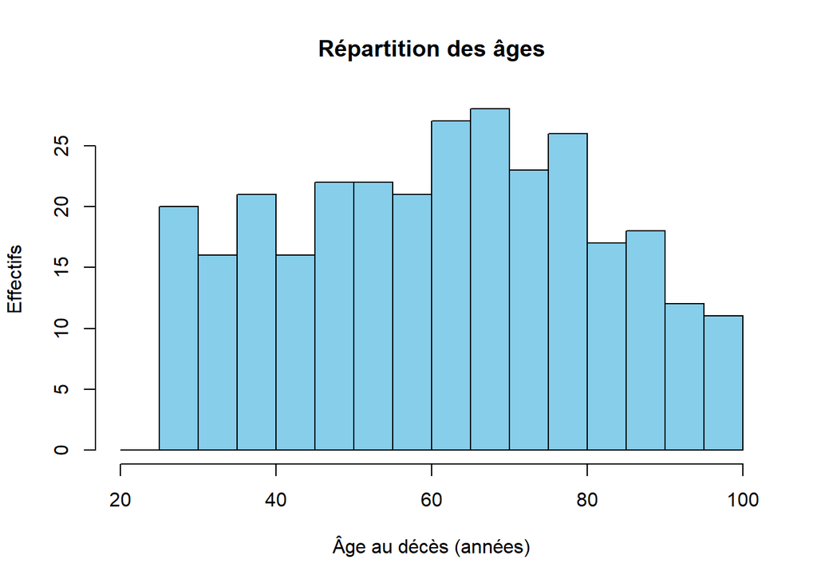

**1. Répartition générale des âges** - La distribution est étalée sur une large plage d’âges allant de 20 à 100 ans.

# 4. Exploration des variables individuelles

Après avoir analysé la variable d’intérêt **l’âge au décès**, nous allons maintenant examiner **les autres variables du dataset** afin de mieux comprendre leur distribution et leur comportement.

**Objectifs de cette section :**

- Identifier **les tendances générales** des variables explicatives.
- Vérifier la **répartition des catégories** pour les variables qualitatives.
- Étudier les **distributions et la dispersion** des variables quantitatives.
- Détecter d’éventuelles **valeurs extrêmes ou anomalies**.

## 4.1 Analyse des variables quantitatives

Nous allons représenter les variables quantitatives sous forme d’histogrammes, permettant de visualiser la fréquence des différentes valeurs observées.

**Analyse**

```
## $`1`
```

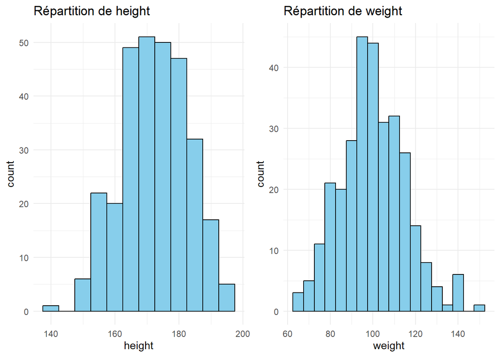

```
##
## $`2`
```

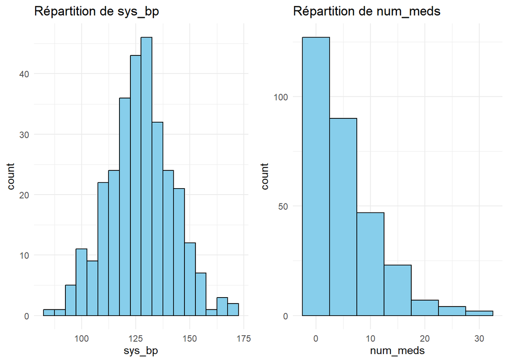

```
##
## $`3`
```

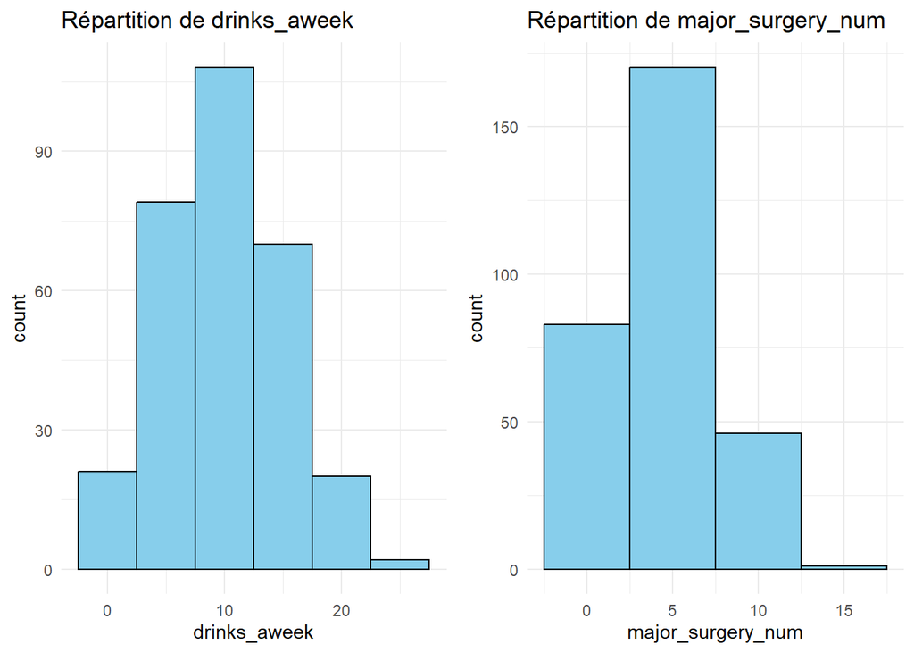

```
##
## $`4`
```

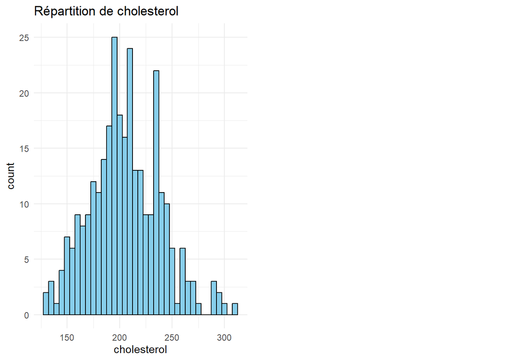

```
##
## attr(,"class")
## [1] "list"      "ggarrange"
```

```r
variables_quantitatives <- c("height", "weight", "sys_bp","num_meds","drinks_aweek","major_surgery_num","cholesterol")

plots <- lapply(variables_quantitatives, function(var) {
  ggplot(Echantillon, aes_string(x = var)) +
    geom_histogram(binwidth = 5, fill = "skyblue", color = "black") +
    ggtitle(paste("Répartition de", var)) +
    theme_minimal()
})

# Afficher les graphiques dans une grille
ggarrange(plotlist = plots, ncol = 2)  #
```

**Analyse Taille**

- La distribution est symétrique, centrée autour de 170-175 cm.
- La courbe est gaussienne, ce qui est typique d’une variable biologique comme la taille.
- La majorité des individus mesurent entre 160 cm et 185 cm.
- Peu d’individus ont une taille inférieure à 150 cm ou supérieure à 195 cm, ce qui indique que les valeurs aberrantes sont rares.

**Analyse poids**

- La distribution est symétrique et centrée autour de 90-100 kg.
- On observe une forme en cloche, proche d’une distribution normale.
- La majorité des individus ont un poids compris entre 70 et 120 kg.
- Très peu d’individus ont un poids inférieur à 60 kg ou supérieur à 140 kg, indiquant une faible présence de valeurs extrêmes.

**Analyse pression arterielle**

- Distribution centrée autour de 125 mmHg.
- Forme gaussienne, bien équilibrée.
- Des valeurs extrêmes sont possibles en dessous de 90 mmHg ou au-dessus de 160 mmHg.

**Analyse consommation d’alcool**

- Distribution asymétrique avec un pic autour de 10 verres/semaine.
- La majorité des individus consomment entre 5 et 15 verres/semaine.
- Quelques valeurs élevées sont visibles (> 20 verres/semaine).

**Analyse nombre d’opérations importantes**

- Distribution asymétrique avec une forte concentration à 3-5 chirurgies.
- Peu d’individus ont subi plus de 10 chirurgies majeures.

### Conclusion

L’analyse des variables montre que les caractéristiques biologiques (poids,tailles…) suivent une distribution relativement homogène tandis que les variables comportementales (nombre de verres,nombre de médicaments) et médicales présentent des asymétries révélant l’existence de profils spécifiques.

## 4.2 Analyse des variables qualitatives

Les variables qualitatives permettent d’explorer des caractéristiques **catégoriques** et de visualiser leur distribution.

```
## $`1`
```

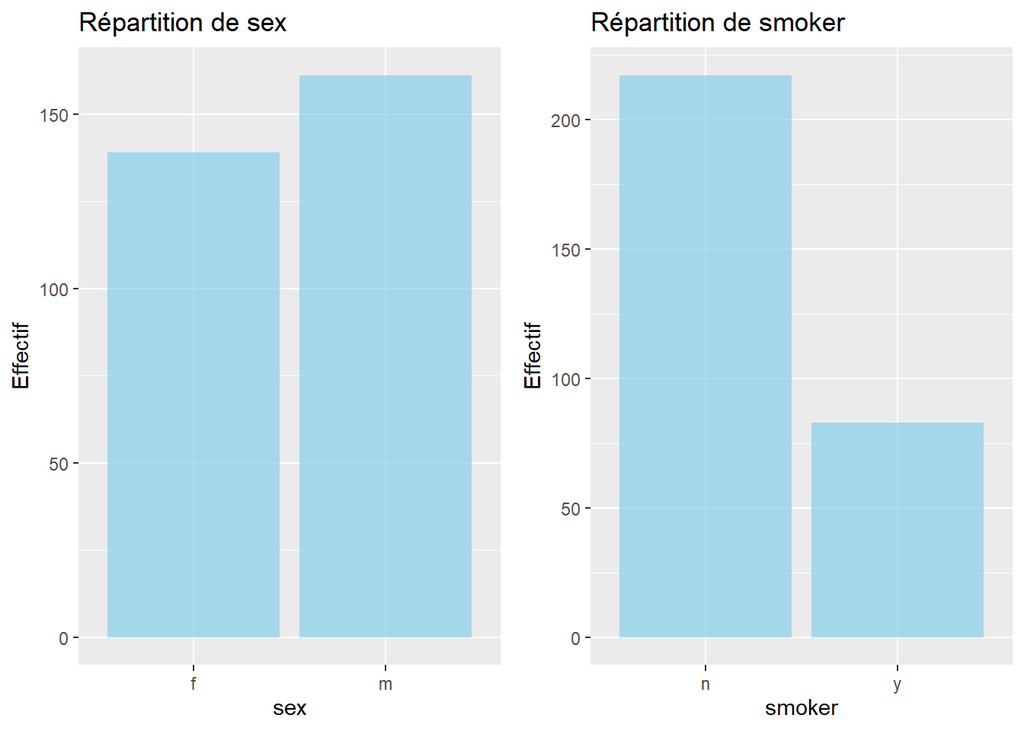

```
##
## $`2`
```

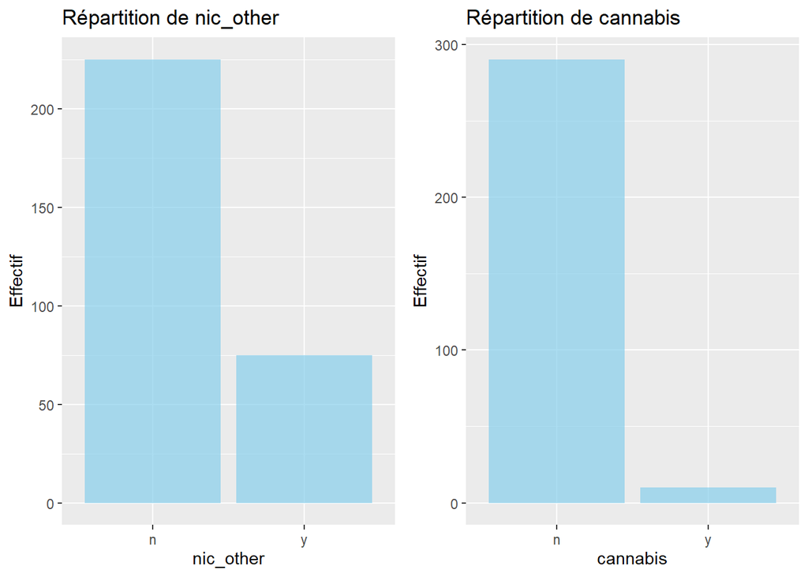

```
##
## $`3`
```

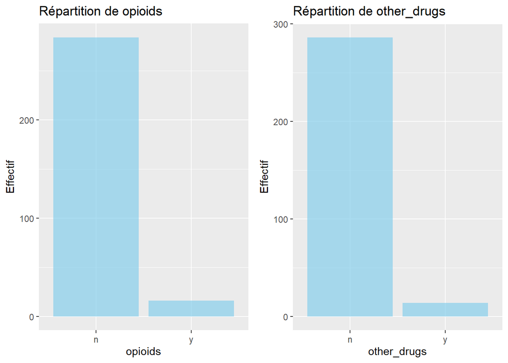

```
##
## $`4`
```

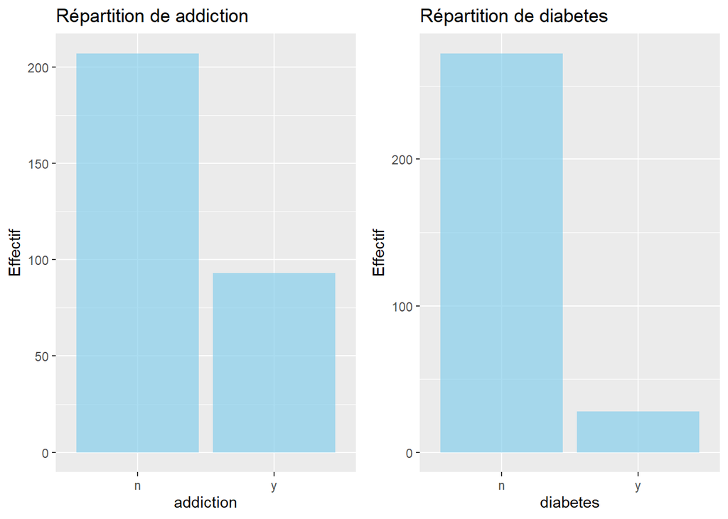

```
##
## $`5`
```

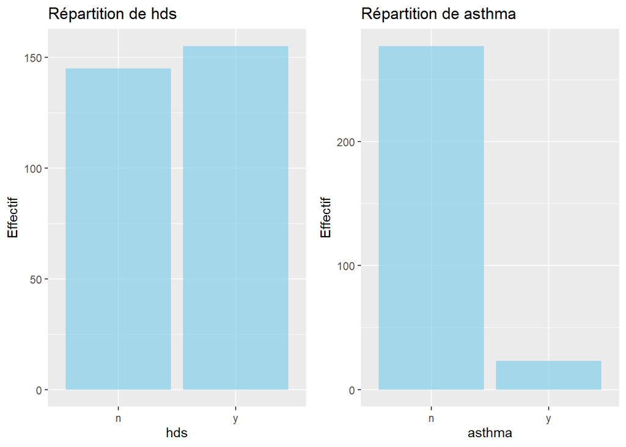

```
##
## $`6`
```

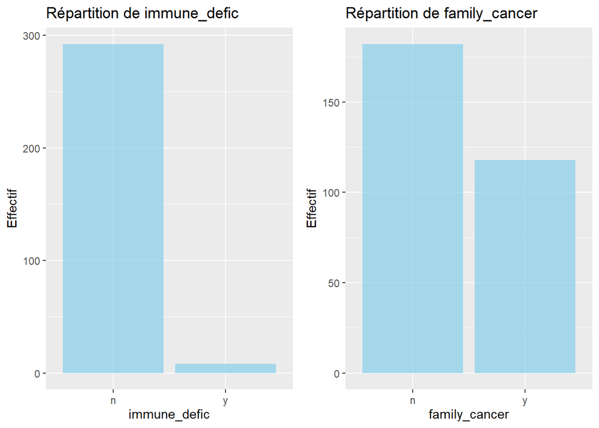

```
##
## $`7`
```

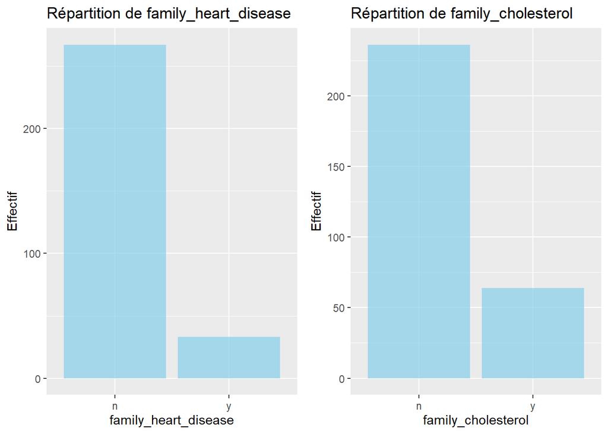

```
##
## $`8`
```

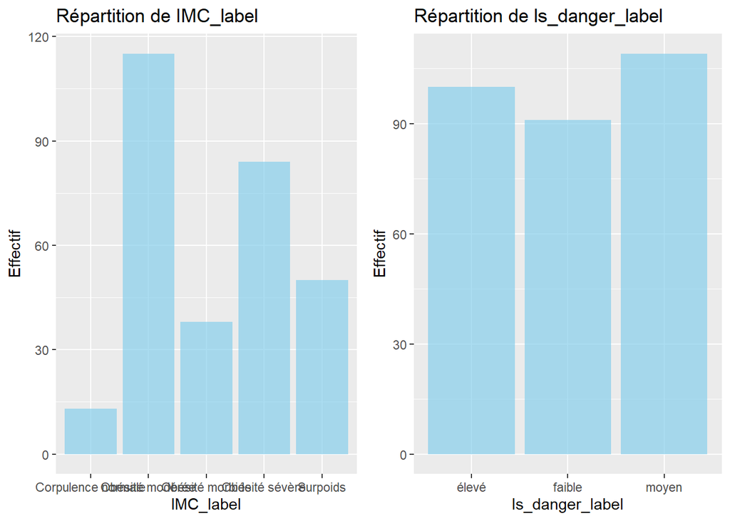

```
##
## $`9`
```

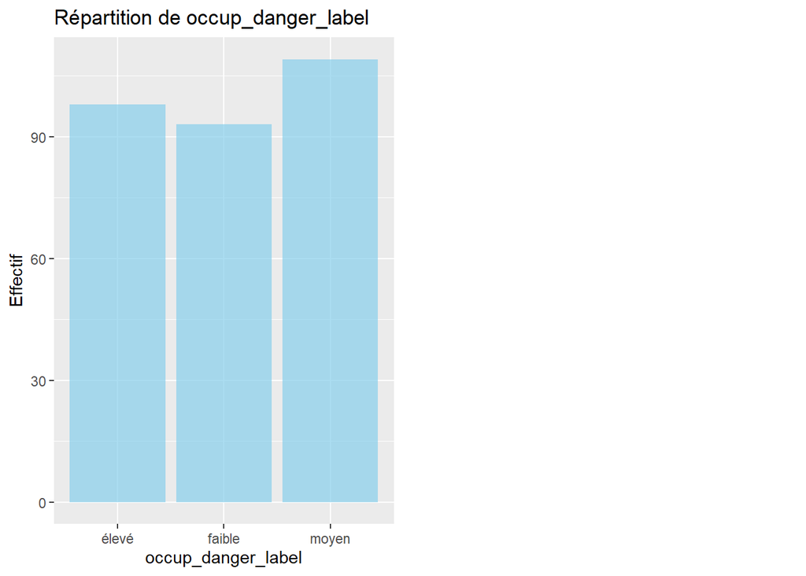

```
##
## attr(,"class")
## [1] "list"      "ggarrange"
```

```r
variables_categoric <- c("sex", "smoker","nic_other","cannabis","opioids","other_drugs","addiction","diabetes","hds","asthma","immune_defic","family_cancer","family_heart_disease","family_cholesterol","IMC_label","ls_danger_label","occup_danger_label")

plot_l = list()


for(v in variables_categoric){
  p = ggplot(Echantillon, aes_string(x = v)) +
  geom_bar( alpha = 0.7,fill = "skyblue") +
  labs(title = paste("Répartition de",v), x = v, y = "Effectif")
  plot_l[[v]] = p
}

ggarrange(plotlist = plot_l, ncol = 2)
```

**Analyse Sexe**

- La population est composée de plus d’hommes (m) que de femmes (f).
- La différence entre les deux groupes est modérée, suggérant un échantillon équilibré.

**Analyse Fumeur**

- Une grande majorité de non-fumeurs (n) comparé aux fumeurs (y).
- Ce déséquilibre peut être intéressant à analyser par rapport à l’âge au décès.

**Analyse autres produits nicotiniques**

- Majorité de non-consommateurs, mais une proportion non négligeable de consommateurs.
- Il serait pertinent de croiser cette variable avec le tabagisme.

**Analyse consommation cannabis**

- Très forte majorité de non-consommateurs.
- Peu de personnes rapportent consommer du cannabis régulièrement.

**Analyse consommation d’opioids**

- La consommation d’opioïdes est extrêmement faible dans cet échantillon.
- L’analyse de son impact sur la mortalité pourrait être limitée par le faible effectif.

**Analyse consommation d’autres drogues**

- Peu de consommateurs déclarés, similaire aux opioïdes.
- Ces substances ayant des effets potentiellement graves, l’association avec l’âge au décès pourrait être explorée.

**Analyse de présence d’une addiction**

- Un nombre notable d’individus déclarent une addiction.
- Cette variable pourrait être corrélée avec la consommation de substances.

**Analyse du diabète**

- Une grande majorité de non-diabétiques.
- Étudier l’impact du diabète sur l’espérance de vie pourrait être pertinent.

**Analyse de présence de maladié cardiaque ou d’AVC**

- Répartition presque équilibrée entre les individus avec ou sans maladies cardiaques.
- Une relation avec l’âge au décès pourrait être étudiée.

**Analyse l’asthme**

- Majorité d’individus non asthmatiques.
- Lien possible entre asthme et espérance de vie.

**Analyse de présence de deficit immunitaire**

- Très peu d’individus souffrent d’une déficience immunitaire.
- Cette variable pourrait être peu informative en raison de son faible effectif.

**Analyse des antécédents familiaux en ce qui concerne les cancer**

- Une part significative des individus a des antécédents familiaux de cancer.
- Cette variable pourrait être explorée pour voir si elle influence l’âge au décès.

**Analyse des antécédents familiaux en ce qui concerne les problèmes cardiaques**

- La majorité des individus n’ont pas d’antécédents familiaux de maladies cardiaques.
- Cette variable pourrait être liée à d’autres facteurs de risque.

### Conclusion

- Certaines variables sont équilibrées (ex : sexe, hds) tandis que d’autres sont fortement déséquilibrées (ex : opioids, immune_defic).
- Les addictions, les maladies et les antécédents familiaux pourraient avoir une influence sur l’âge au décès et méritent une analyse plus approfondie.

# 5.Croisements entre l’âge et des variables explicatives

## 5.1 Variables qualitatives

Les boxplots sont un outil puissant pour évaluer si une variable qualitative influence notre variable d’intérêt (l’âge).

### Boxplots des Variables Qualitatives Potentiellement Non Pertinentes

Dans cette section, nous examinons certaines variables qualitatives susceptibles de ne pas être pertinentes pour l’explication de notre variable d’intérêt, l’âge au décès.

**Objectif :**

L’objectif est de visualiser ces variables à l’aide de boxplots pour observer si elles présentent des différences notables entre leurs catégories. Ensuite, nous effectuerons un test ANOVA afin de déterminer si ces différences sont statistiquement significatives.

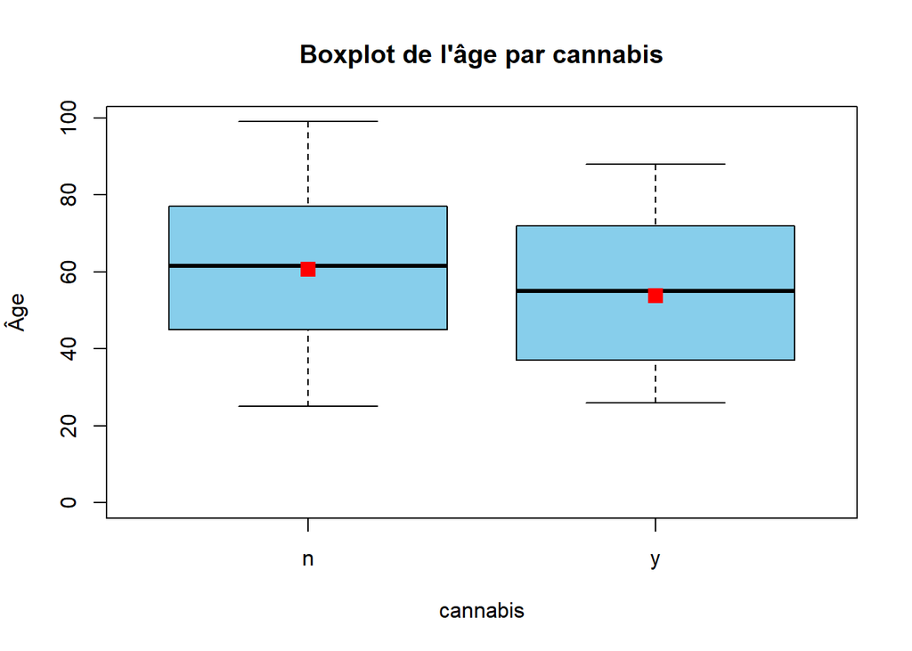

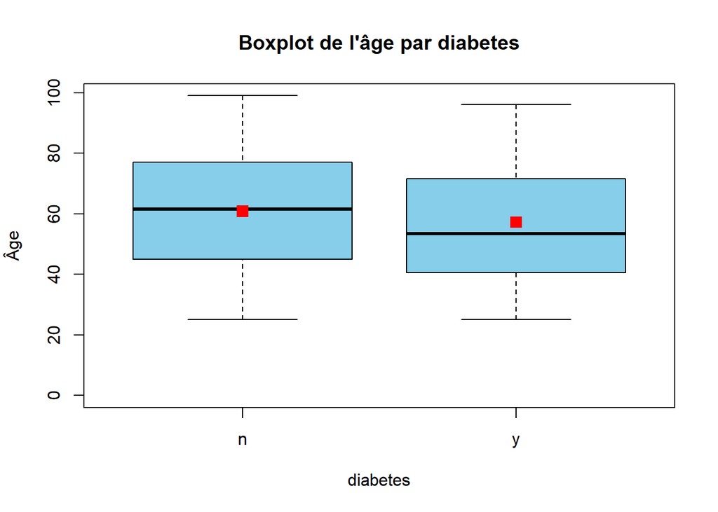

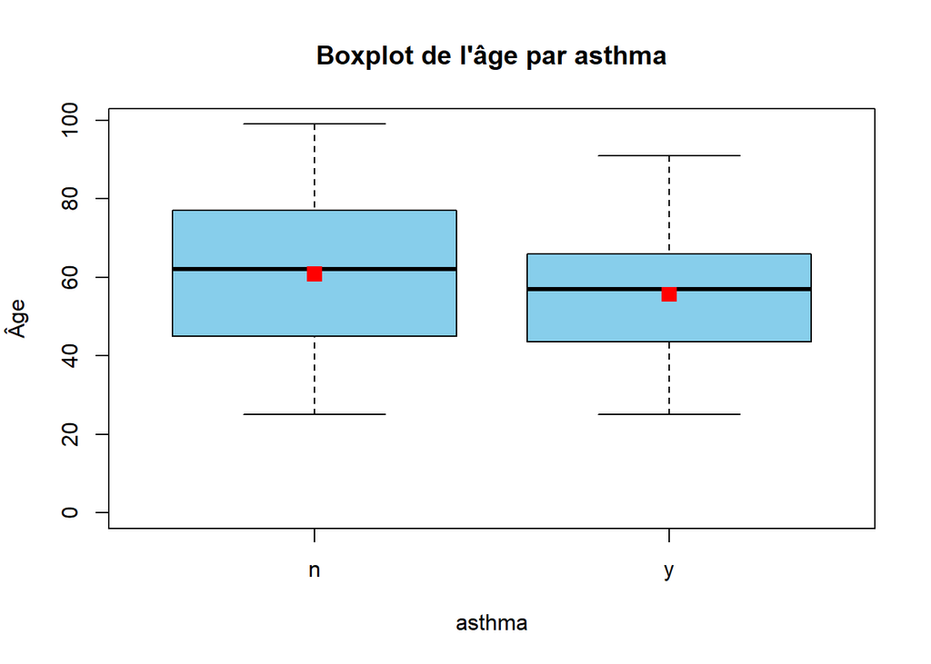

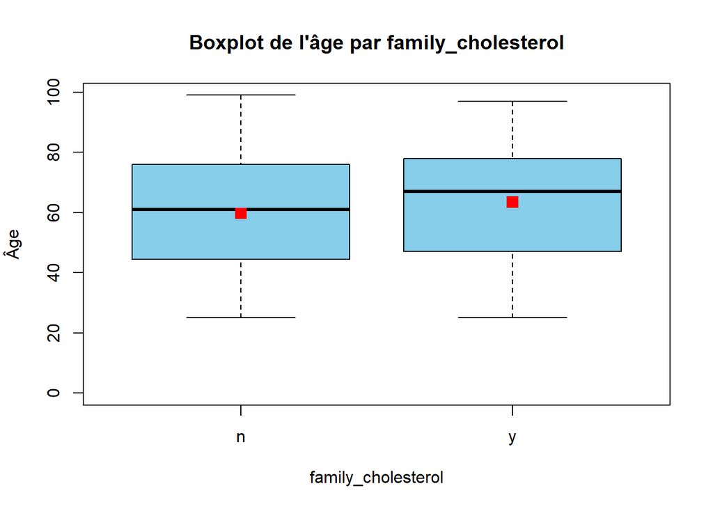

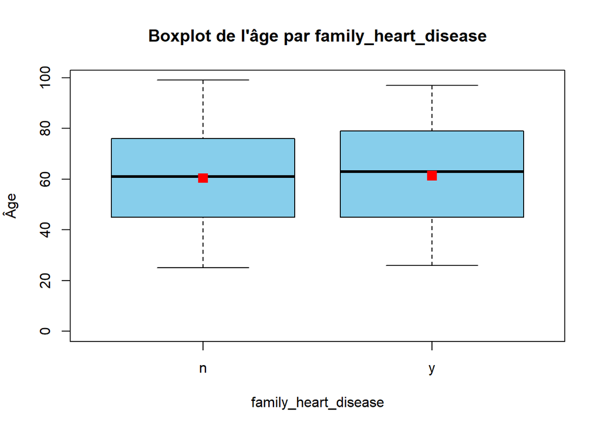

```r
summary(aov(age ~ cannabis + diabetes + asthma + family_cholesterol + family_heart_disease, data = Echantillon))
```

```
##                       Df Sum Sq Mean Sq F value Pr(>F)
## cannabis               1    461   460.7   1.173  0.280
## diabetes               1    370   369.6   0.941  0.333
## asthma                 1    647   646.8   1.647  0.200
## family_cholesterol     1    833   832.9   2.120  0.146
## family_heart_disease   1     12    12.1   0.031  0.861
## Residuals            294 115477   392.8
```

**Analyse des Résultats du Test ANOVA**

Hypothèses du test Anova :

H0 : Le coefficient associé a la variable est égal à 0

H1 : Le coefficient associé est différent de 0

Le tableau ci-dessus présente les résultats du test ANOVA réalisé sur les variables qualitatives cannabis, diabetes, asthma, et family_cholesterol, afin de déterminer si elles ont un effet significatif sur la variable d’intérêt, l’âge au décès (age).

Interprétation des résultats Nous avons fixé Alpha = 0.05 comme seuil de signification.

Les p-values obtenues pour chaque variables sont supérieures à 0.05, indiquant que ces variables n’ont pas d’impact statistiquement significatif sur l’âge au décès.

### Boxplots des variables potentiellement pertinentes

#### boxplot de l’âge par sex

[figure not shown]

#### Test ANOVA 1 sur le facteur “Sex”

```
##              Df Sum Sq Mean Sq F value Pr(>F)
## sex           1   2356  2355.8   6.081 0.0142 *
## Residuals   298 115443   387.4
## ---
## Signif. codes:  0 '***' 0.001 '**' 0.01 '*' 0.05 '.' 0.1 ' ' 1
```

**Hypothèses**

- **H0** : effet type de sexe nul
- **H1** : effet type de sexe non nul

Le facteur “Sex” est de type qualitatif et possède 2 niveaux : “f” et “m”. Pour estimer si le facteur “Sex” a un effet sur l’âge de décès, nous pouvons analyser la p-value retournée par le moodèle ANNOVA 1.

**Analyses**

[output not shown]

On en conclue donc que le test est significatif. H0 est rejeté et on en conclue que le fait que le sex (“f” ou “m”) a un impact significatif sur l’åge de décès.

**De la même manière**, nous allons poser les mêmes hypothèses et faire les mêmes tests pour toutes les variables qualitatives restantes ce qui nous donne :

#### boxplot de l’âge par consommation d’autres produits nicotiniques

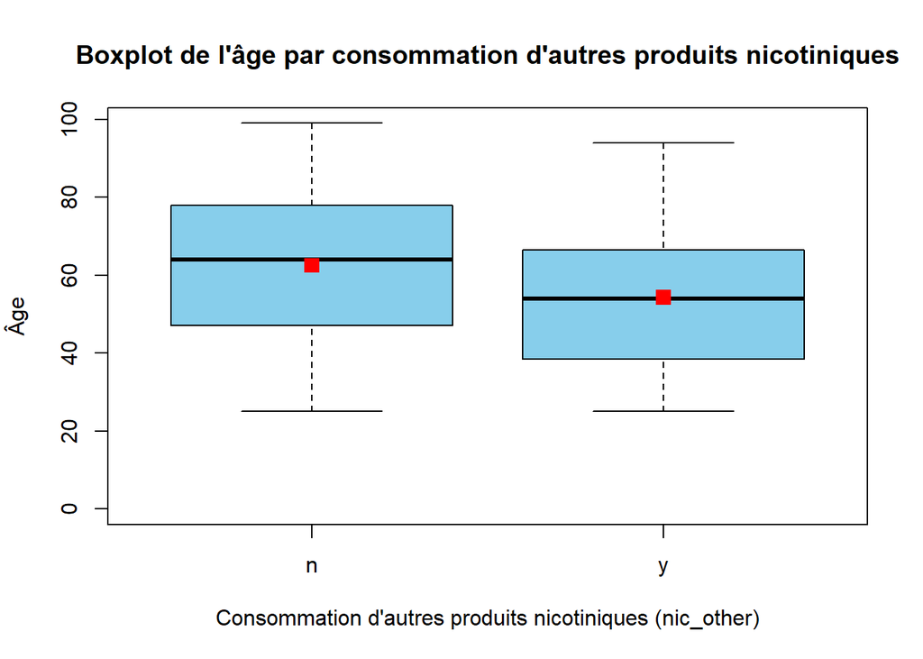

#### Test ANOVA 1 sur le facteur “nic_other”

```
##              Df Sum Sq Mean Sq F value  Pr(>F)
## nic_other     1   3754    3754   9.808 0.00191 **
## Residuals   298 114045     383
## ---
## Signif. codes:  0 '***' 0.001 '**' 0.01 '*' 0.05 '.' 0.1 ' ' 1
```

**Analyses**

```
    P-Value  <   0,05 = Alpha
```

Donc que le test est significatif. H0 est rejeté et on peut dire la consommation d’autres subsatances nicotiniques influence l’espérance de vie.

#### boxplot de l’âge par opioids

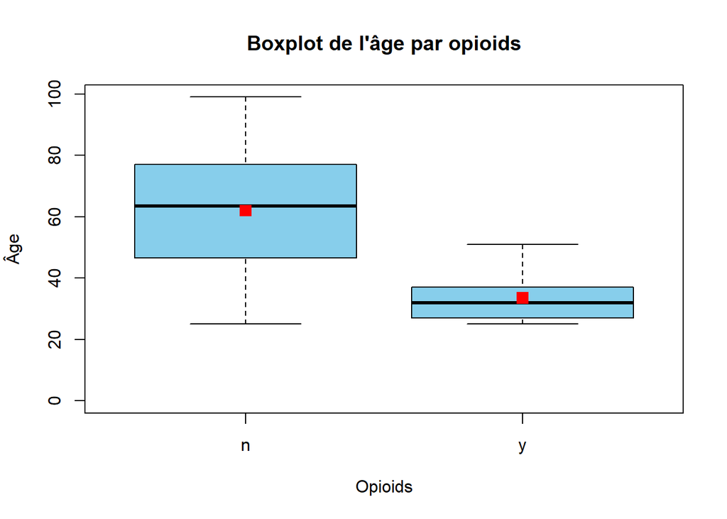

#### Test ANOVA 1 sur le facteur “opioids”

```
##              Df Sum Sq Mean Sq F value   Pr(>F)
## opioids       1  12240   12240   34.55 1.11e-08 ***
## Residuals   298 105559     354
## ---
## Signif. codes:  0 '***' 0.001 '**' 0.01 '*' 0.05 '.' 0.1 ' ' 1
```

**Analyses**

```
P-Value  <   0,05 = Alpha
```

Donc que le test est significatif. H0 est rejeté et on peut dire que la consommation d’opioids a un impact significatif sur l’åge de décès.

#### boxplot de l’âge par addiction

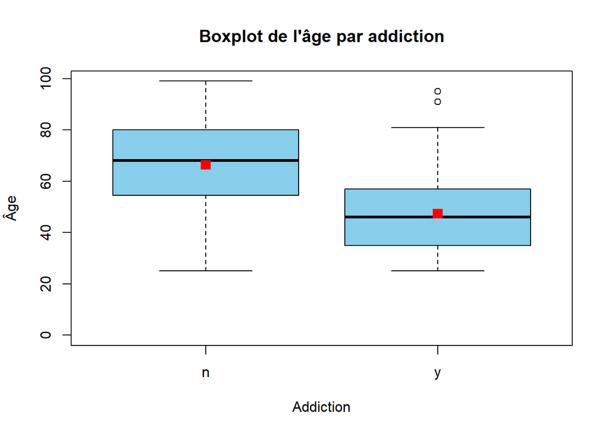

#### Test ANOVA 1 sur le facteur “addiction”

```
##              Df Sum Sq Mean Sq F value   Pr(>F)
## addiction     1  23310   23310   73.51 5.53e-16 ***
## Residuals   298  94489     317
## ---
## Signif. codes:  0 '***' 0.001 '**' 0.01 '*' 0.05 '.' 0.1 ' ' 1
```

**Analyses**

```
P-Value <   0,05 = Alpha
```

On en conclue donc que le test est significatif. Ce qui signifie qu’avoir une addiction a un impact significatif sur l’åge de décès.

#### boxplot de l’âge par hds

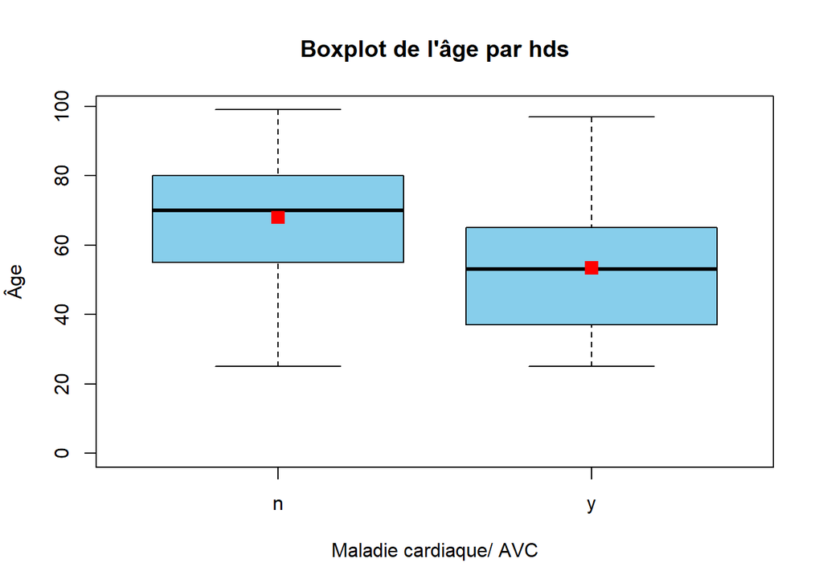

#### Test ANOVA 1 sur le facteur “hds”

```
##              Df Sum Sq Mean Sq F value   Pr(>F)
## hds           1  15695   15695   45.81 6.92e-11 ***
## Residuals   298 102103     343
## ---
## Signif. codes:  0 '***' 0.001 '**' 0.01 '*' 0.05 '.' 0.1 ' ' 1
```

**Analyses**

```
P-Value  <   0,05 = Alpha
```

On en conclue donc que le test est significatif. H0 est rejeté donc le fait d’avoir des problèmes cardiaques ou d’avoir fais un AVC a un impact significatif sur l’åge de décès.

#### boxplot de l’âge par immune_defic

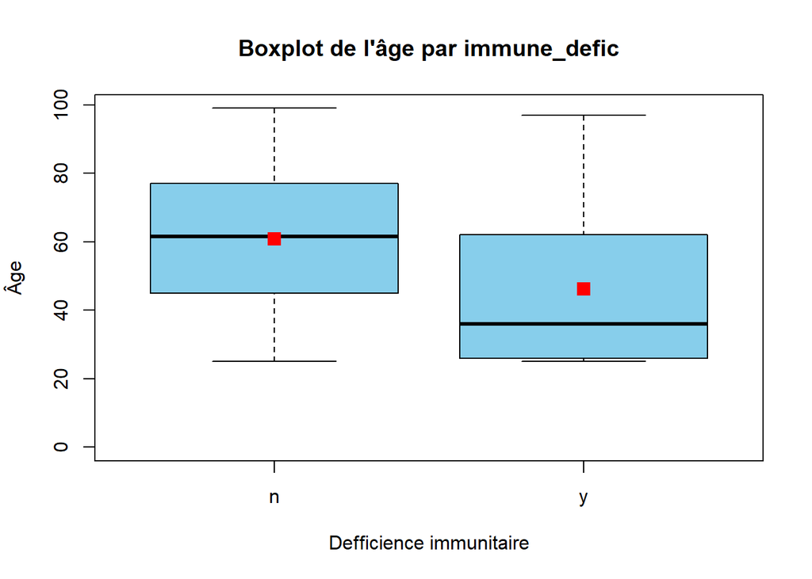

#### Test ANOVA 1 sur le facteur “immune_defic”

```
##               Df Sum Sq Mean Sq F value Pr(>F)
## immune_defic   1   1663  1662.8   4.267 0.0397 *
## Residuals    298 116136   389.7
## ---
## Signif. codes:  0 '***' 0.001 '**' 0.01 '*' 0.05 '.' 0.1 ' ' 1
```

**Analyses**

```
P-Value  <   0,05 = Alpha
```

On en conclue donc que le test est significatif. H0 est rejeté donc le fait d’avoir un système immunitaire affaible a un impact significatif sur l’åge de décès.

#### boxplot de l’âge par other_drugs

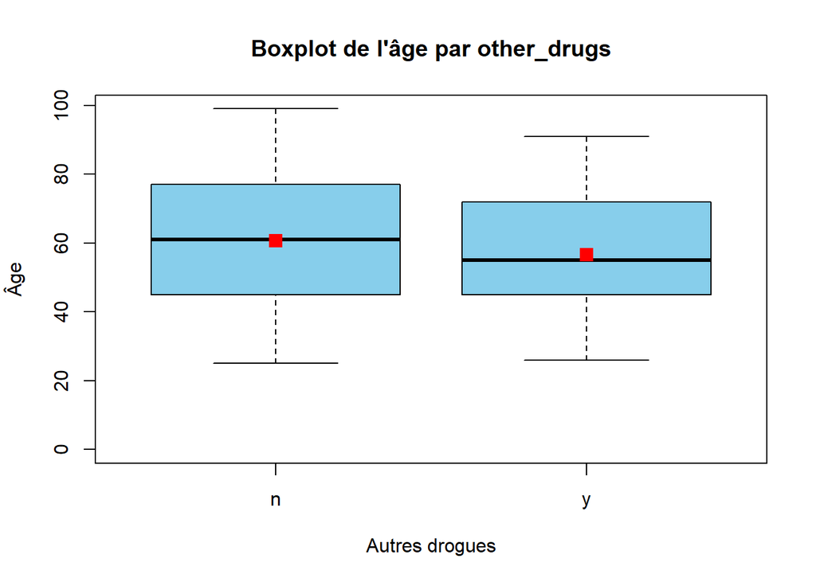

#### Test ANOVA 1 sur le facteur “other_drugs”

```
##              Df Sum Sq Mean Sq F value Pr(>F)
## other_drugs   1    215   215.5   0.546  0.461
## Residuals   298 117583   394.6
```

**Analyses**

```
P-Value  >   0,05 = Alpha
```

On en conclue donc que le test n’est pas significatif. H0 n’est pas rejeté et on en conclue que la prise d’autres drogues n’a pas un impact significatif sur l’åge de décès.

#### boxplot de l’âge par smoker

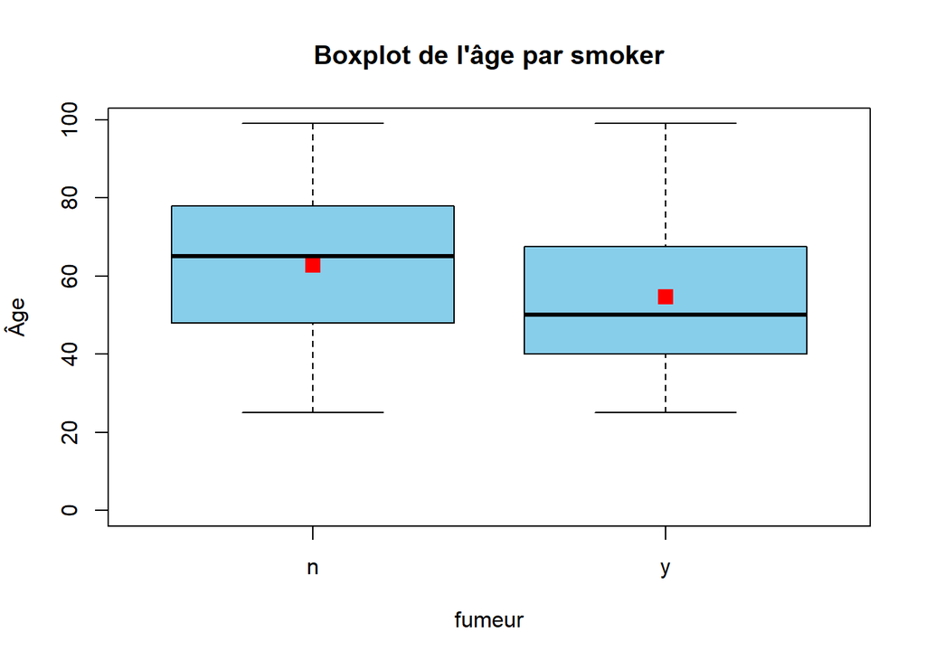

#### Test ANOVA 1 sur le facteur “smoker”

```
##              Df Sum Sq Mean Sq F value Pr(>F)
## smoker        1   3923    3923   10.27 0.0015 **
## Residuals   298 113876     382
## ---
## Signif. codes:  0 '***' 0.001 '**' 0.01 '*' 0.05 '.' 0.1 ' ' 1
```

**Analyses**

```
P-Value  <   0,05 = Alpha
```

On en conclue donc que le test est significatif. H0 est rejeté et on en conclue que le fait de fumer a un impact significatif sur l’åge de décès.

#### boxplot de l’âge par “family_cancer”

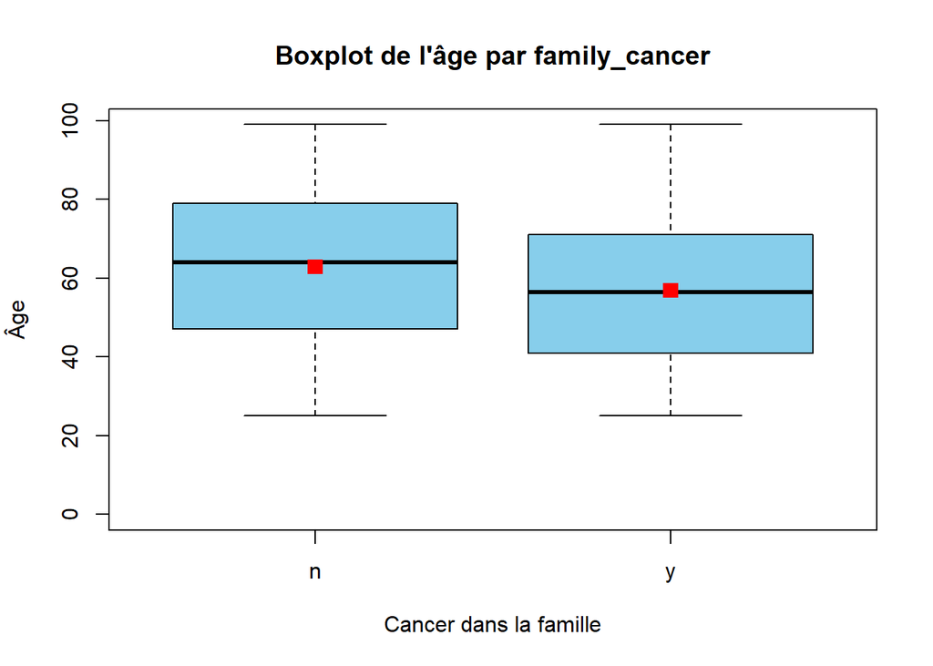

#### Test ANOVA 1 sur le facteur “family_cancer”

```
##                Df Sum Sq Mean Sq F value Pr(>F)
## family_cancer   1   2557  2557.2   6.612 0.0106 *
## Residuals     298 115242   386.7
## ---
## Signif. codes:  0 '***' 0.001 '**' 0.01 '*' 0.05 '.' 0.1 ' ' 1
```

**Analyses**

```
P-Value  <   0,05 = Alpha
```

On en conclue donc que le test est significatif. H0 est rejeté et on en conclue que l’effet antécédants de cancer dans la famille a un impact significatif sur l’åge de décès.

#### Boxplot pour ‘occup_danger_label’

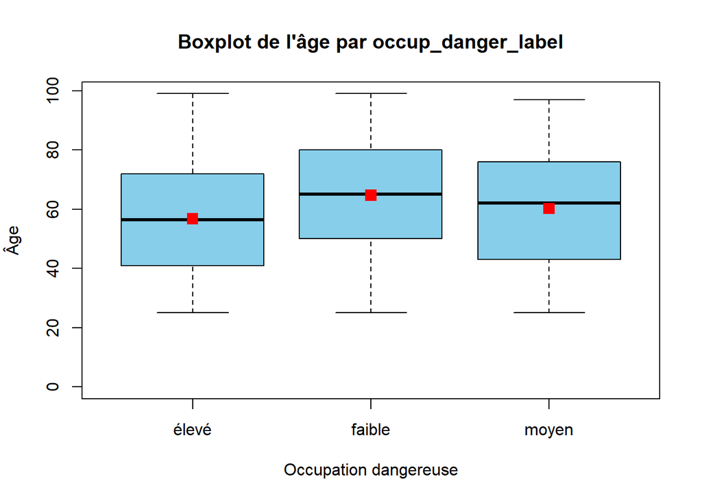

#### Test ANOVA 1 sur le facteur “occup_danger_label”

```
##                     Df Sum Sq Mean Sq F value Pr(>F)
## occup_danger_label   2   3028  1514.0   3.918 0.0209 *
## Residuals          297 114771   386.4
## ---
## Signif. codes:  0 '***' 0.001 '**' 0.01 '*' 0.05 '.' 0.1 ' ' 1
```

**Analyses**

```
P-Value  <   0,05 = Alpha
```

On en conclue donc que le test est significatif. H0 est rejeté et on en conclue que le niveau de danger de l’emploi a un impact significatif sur l’åge de décès.

#### Boxplot pour ‘ls_danger_label’

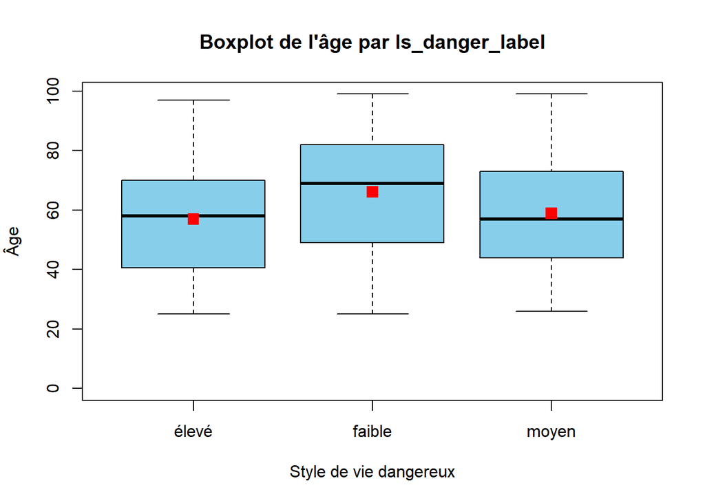

#### Test ANOVA 1 sur le facteur “ls_danger_label”

```
##                  Df Sum Sq Mean Sq F value  Pr(>F)
## ls_danger_label   2   4378  2188.9   5.732 0.00361 **
## Residuals       297 113421   381.9
## ---
## Signif. codes:  0 '***' 0.001 '**' 0.01 '*' 0.05 '.' 0.1 ' ' 1
```

**Analyses**

```
P-Value  <   0,05 = Alpha
```

On en conclue donc que le test est significatif. H0 est rejeté et on en conclue que le niveau de danger de l’environnement dans lequel nous vivons a un impact significatif sur l’åge de décès.

#### Boxplot pour ‘IMC_label’

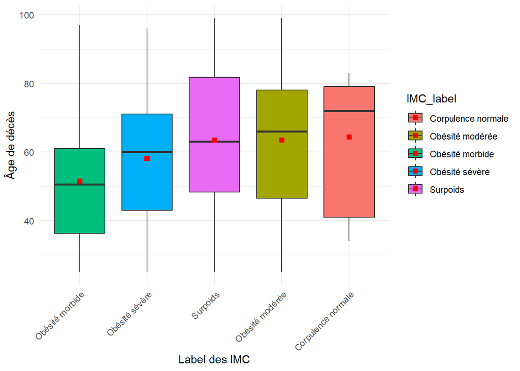

#### Test ANOVA 1 sur le facteur “IMC_label”

```
##              Df Sum Sq Mean Sq F value  Pr(>F)
## IMC_label     4   5178  1294.4   3.391 0.00988 **
## Residuals   295 112621   381.8
## ---
## Signif. codes:  0 '***' 0.001 '**' 0.01 '*' 0.05 '.' 0.1 ' ' 1
```

**Analyses**

```
P-Value  <   0,05 = Alpha
```

On en conclue donc que le test est significatif. H0 est rejeté et on en conclue que notre IMC a un impact significatif sur l’åge de décès.

### Conclusion

Les variables smoker et family_heart_disease semblent impacter légèrement sur l’age de décès cependant cet impact est moins important que pour variables citées précédemment, il s’agira donc de réaliser par la suite des tests pour décider ou non de garder ces variables.

## 5.2 Variables quantitatives

Pour analyser l’impact des variables quantitatives, nous allons créer plusieurs modèles simples pour chacunes de ces variables afin de voir si elles impactent ou non l’âge de décès

### Variable Age en fonction du poids

#### Modélisation linéaire simple

Dans un premier temps on créer notre modèle et on estime les paramètres de celui-ci à l’aide des moindres carrés. Puis on visualise graphiquement nos individus en fonction de la droite de régression

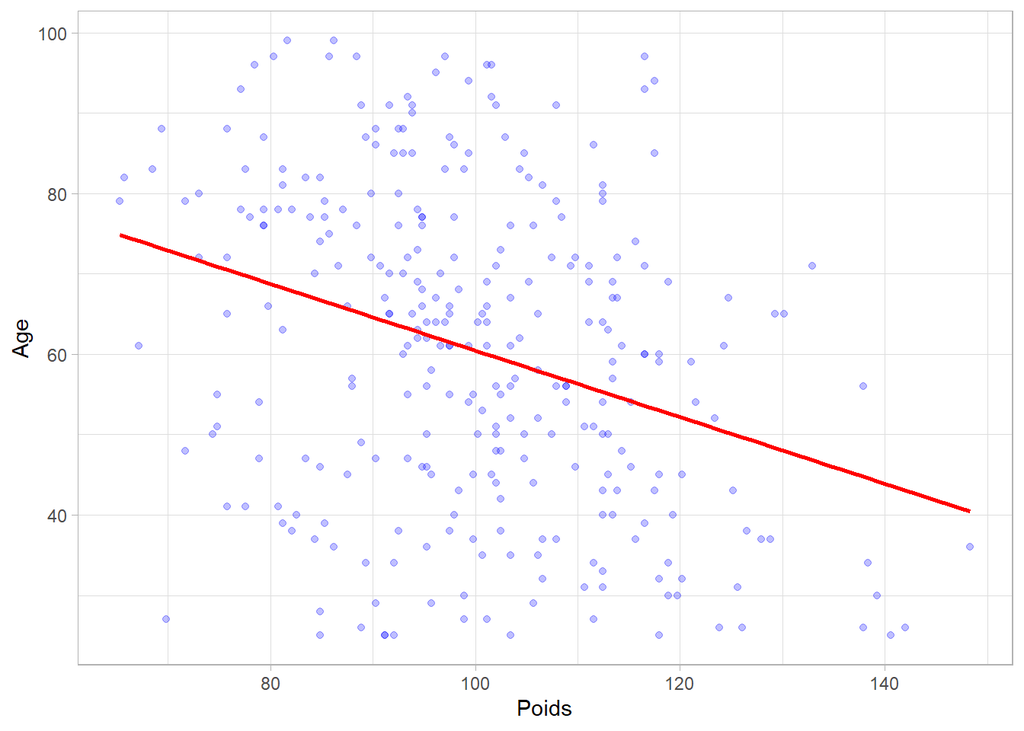

#### Équation du modèle

```
## [1] "Age =  101.91 -0.41 * Weight"
```

```
## [1] "R² =  0.1"
```

Ici on écrit le modèle ajusté ainsi que le R2 du modèle qui est un indicateur de la qualité d’explication de notre modèle. Il va aussi nous permettre de comparer nos différents modèles entres eux et trouver le meilleur.

#### Vérification des hypothèse des résidus

Pour valider notre modèle, nous devons vérifier les hypothèses liés a celui-ci

1 - les erreurs sont centrées

En faisant la moyenne, on vérifie qu’elles sont centrées

2 - les erreurs sont de même variance

**Breush Pagan** test : **H0** : Les erreurs sont de même variance

**H1** : Les erreurs ont des variances différentes

3 - les erreurs suivent une loi normale

**Shapiro wilk** test : **H0** : Les erreurs suivent une loi normale

**H1** : Les erreurs ne suivent pas une loi normale

4 - les erreurs sont non-corrélées/ indépendantes

**Durbin watson** test :

**H0** : Les erreurs sont non-corrélées

**H1** : Les erreurs sont corrélées

```
## [1] -8.94701e-16
```

```
##
##  studentized Breusch-Pagan test
##
## data:  model1
## BP = 2.8155, df = 1, p-value = 0.09336
```

```
##
##  Shapiro-Wilk normality test
##
## data:  model1$residuals
## W = 0.98838, p-value = 0.01668
```

```
##
##  Durbin-Watson test
##
## data:  model1
## DW = 2.078, p-value = 0.7523
## alternative hypothesis: true autocorrelation is greater than 0
```

#### Interprétation des résultats

**Qualité du modèle :** La pente négative signifie que plus le poids est élevé, plus l’âge de décès diminue.

**Hypothèse des résidus :** Moyenne proche de 0 :validé

Normalité : non-validée, p-value < 0.05

Indépendance des erreurs : validée, statistique de test proche de 2 donc non-colinéarité

**Conclusion :** La qualité du modèle moyenne ansi que les hypothèses non validées nous pemrettent de conclure que le modèle linéaire n’est pas suffisant pour expliquer la relation entre le poids et l’âge de décès.

### Variable Age en fonction de la taille

#### Modélisation linéaire simple

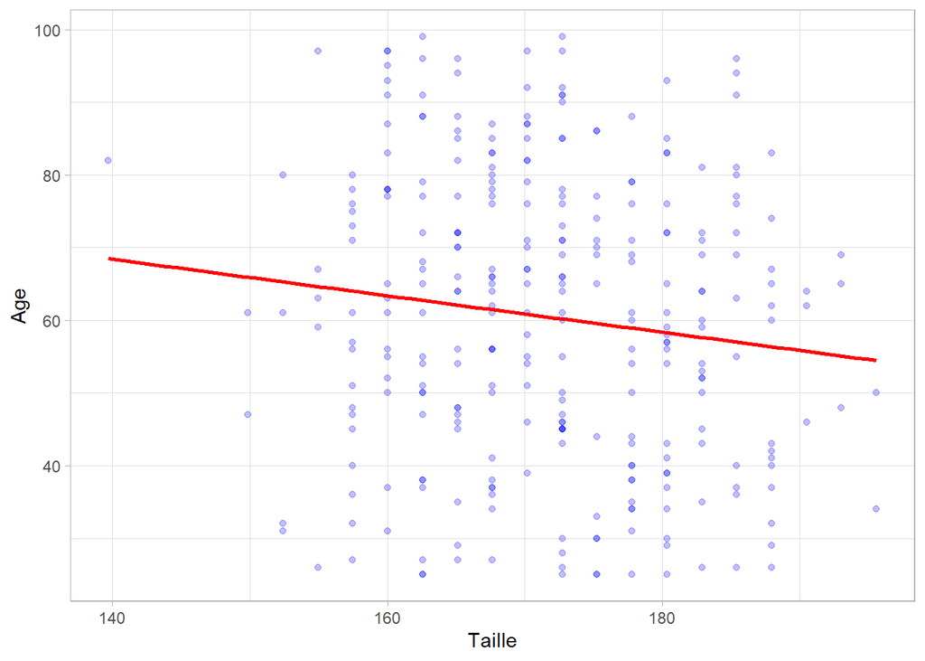

#### Équation du modèle

```
## [1] "Age =  103.53 -0.25 * Height"
```

```
## [1] "R² =  0.02"
```

#### Vérification des hypothèse des résidus

```
## [1] -1.970646e-15
```

```
##
##  studentized Breusch-Pagan test
##
## data:  model2
## BP = 1.4833, df = 1, p-value = 0.2233
```

```
##
##  Shapiro-Wilk normality test
##
## data:  model2$residuals
## W = 0.97526, p-value = 4.775e-05
```

```
##
##  Durbin-Watson test
##
## data:  model2
## DW = 2.1111, p-value = 0.832
## alternative hypothesis: true autocorrelation is greater than 0
```

#### Interprétation des résultats

**Qualité du modèle :** La pente négative signifie que plus la taille est élevée, plus l’âge de décès diminue.

**Hypothèse des résidus :** Moyenne proche de 0 :validée

Homoscédasticité : validée, p-value supérieur à 0.05

Normalité : non-validée, p-value < 0.05

Indépendance des erreurs : validée, statistique de test proche de 2 donc non-colinéarité

**Conclusion :** La qualité du modèle mauvaise ansi que l’hypothèse non validée nous permet de conclure que le modèle linéaire n’est pas suffisant pour expliquer la relation entre la taille et l’âge de décès.

### Variable Age en fonction du sys_bp

#### Modélisation linéaire simple

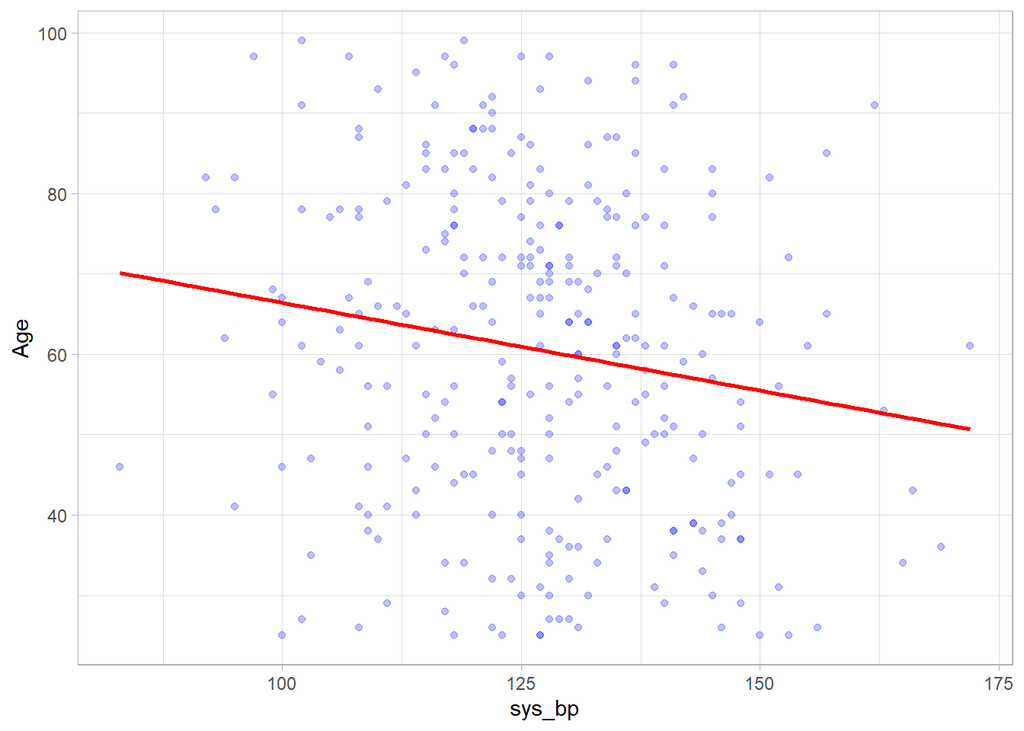

#### Équation du modèle

```
## [1] "Age =  88.29 -0.22 * sys_bp"
```

```
## [1] "R² =  0.03"
```

#### Vérification des hypothèse des résidus

```
## [1] -1.309161e-15
```

```
##
##  studentized Breusch-Pagan test
##
## data:  model3
## BP = 1.0295, df = 1, p-value = 0.3103
```

```
##
##  Shapiro-Wilk normality test
##
## data:  model3$residuals
## W = 0.97804, p-value = 0.0001464
```

```
##
##  Durbin-Watson test
##
## data:  model3
## DW = 2.0814, p-value = 0.7607
## alternative hypothesis: true autocorrelation is greater than 0
```

#### Interprétation des résultats

**Qualité du modèle :** La pente négative signifie que plus la pression arterielle est élevée, plus l’âge de décès diminue.

**Hypothèse des résidus :** Moyenne proche de 0 :validée

Homoscédasticité : validée, p-value supérieur à 0.05

Normalité : non-validée, p-value < 0.05

Indépendance des erreurs : validée, statistique de test proche de 2 donc non-colinéarité

**Conclusion :** La qualité du modèle mauvaise ansi que l’hypothèse non validée nous permet de conclure que le modèle linéaire n’est pas suffisant pour expliquer la relation entre la pression arterielle et l’âge de décès.

### Variable Age en fonction du nombre de médicaments pris

#### Modélisation linéaire simple

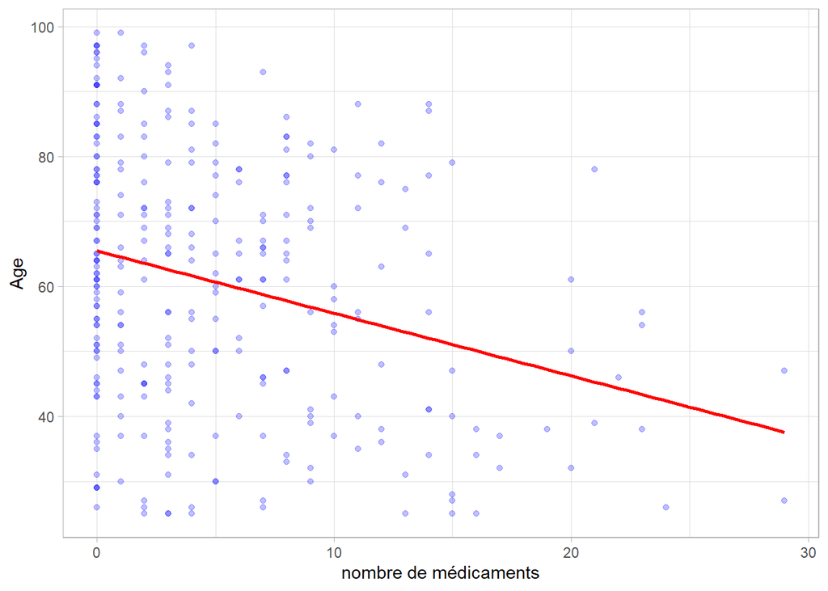

#### Équation du modèle

```
## [1] "Age =  65.47 -0.96 * Num_meds"
```

```
## [1] "R² =  0.08"
```

#### Vérification des hypothèse des résidus

```
## [1] 1.208871e-16
```

```
##
##  studentized Breusch-Pagan test
##
## data:  model4
## BP = 2.3146, df = 1, p-value = 0.1282
```

```
##
##  Shapiro-Wilk normality test
##
## data:  model4$residuals
## W = 0.9775, p-value = 0.000117
```

```
##
##  Durbin-Watson test
##
## data:  model4
## DW = 2.1197, p-value = 0.8507
## alternative hypothesis: true autocorrelation is greater than 0
```

#### Interprétation des résultats

**Qualité du modèle :** La pente négative signifie que plus le nombre de médicaments est élevé, plus l’âge de décès diminue.

**Hypothèse des résidus :** Moyenne proche de 0 :validée

Homoscédasticité : validée, p-value supérieur à 0.05

Normalité : non-validée, p-value < 0.05

Indépendance des erreurs : validée, statistique de test proche de 2 donc non-colinéarité

### Variable Age en fonction du nombre de verre d’alcool

#### Modélisation linéaire simple

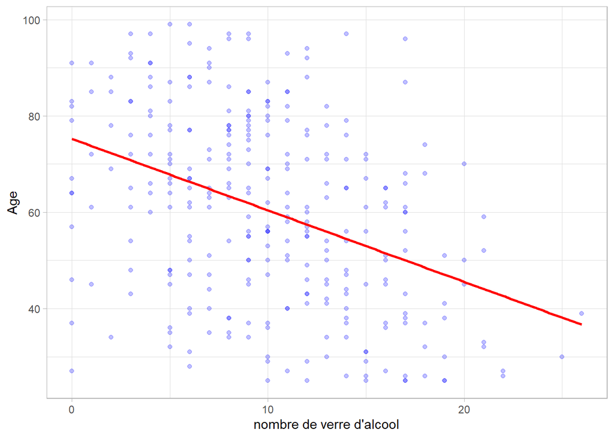

#### Équation du modèle

```
## [1] "Age =  75.23 -1.48 * drinks_aweek"
```

```
## [1] "R² =  0.15"
```

#### Vérification des hypothèse des résidus

```
## [1] -1.154256e-15
```

```
##
##  studentized Breusch-Pagan test
##
## data:  model5
## BP = 2.0806, df = 1, p-value = 0.1492
```

```
##
##  Shapiro-Wilk normality test
##
## data:  model5$residuals
## W = 0.98991, p-value = 0.03616
```

```
##
##  Durbin-Watson test
##
## data:  model5
## DW = 2.0426, p-value = 0.6412
## alternative hypothesis: true autocorrelation is greater than 0
```

#### Interprétation des résultats

**Qualité du modèle :** La pente négative signifie que plus la personne boit de verres d’alcool dans la semaine, plus l’âge de décès diminue.

**Hypothèse des résidus :** Moyenne proche de 0 :validée

Normalité : non-validée, p-value < 0.05

Indépendance des erreurs : validée, statistique de test proche de 2 donc non-colinéarité

**Conclusion :** La qualité du modèle moyenne ansi que les hypothèses non validées nous permettent de conclure que le modèle linéaire n’est pas suffisant pour expliquer la relation entre la quantité d’alcool consommée et l’âge de décès.

### Variable Age en fonction du nombre d’opération importantes

#### Modélisation linéaire simple

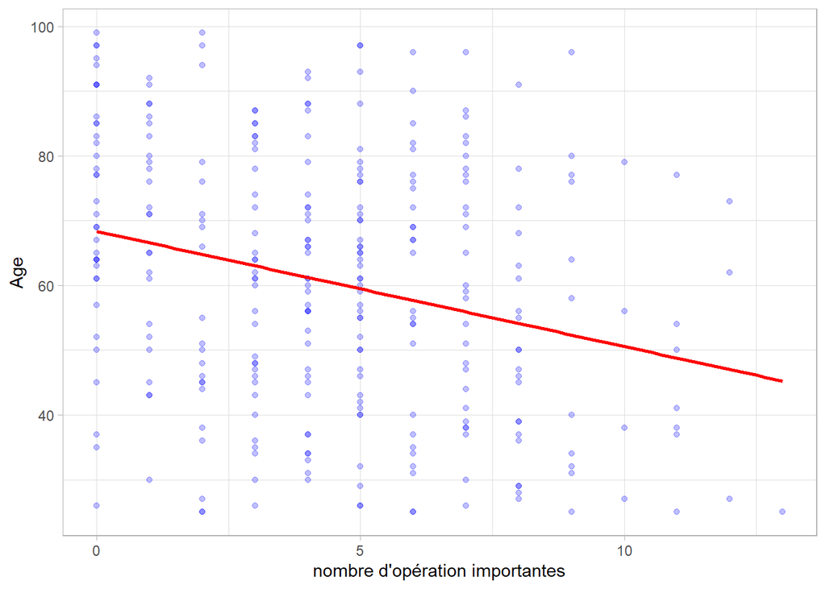

#### Équation du modèle

```
## [1] "Age =  68.35 -1.78 * major_surgery_num"
```

```
## [1] "R² =  0.07"
```

#### Vérification des hypothèse des résidus

```
## [1] -1.119429e-15
```

```
##
##  studentized Breusch-Pagan test
##
## data:  model6
## BP = 0.1274, df = 1, p-value = 0.7211
```

```
##
##  Shapiro-Wilk normality test
##
## data:  model6$residuals
## W = 0.98237, p-value = 0.0009484
```

```
##
##  Durbin-Watson test
##
## data:  model6
## DW = 2.1083, p-value = 0.8248
## alternative hypothesis: true autocorrelation is greater than 0
```

#### Interprétation des résultats

**Qualité du modèle :** La pente négative signifie que plus la personne a subi des opérations importantes, moins l’âge de décès est important.

**Hypothèse des résidus :** Moyenne proche de 0 :validée

Homoscédasticité : validée, p-value supérieur à 0.05

Normalité : non-validée, p-value < 0.05

Indépendance des erreurs : validée, statistique de test proche de 2 donc non-colinéarité

**Conclusion :** La qualité du modèle mauvaise ansi que l’hypothèse non validée nous permet de conclure que le modèle linéaire n’est pas suffisant pour expliquer la relation entre le nombre d’opérations importantes vécues et l’âge de décès.

### Variable Age en fonction du cholesterol

#### Modélisation linéaire simple

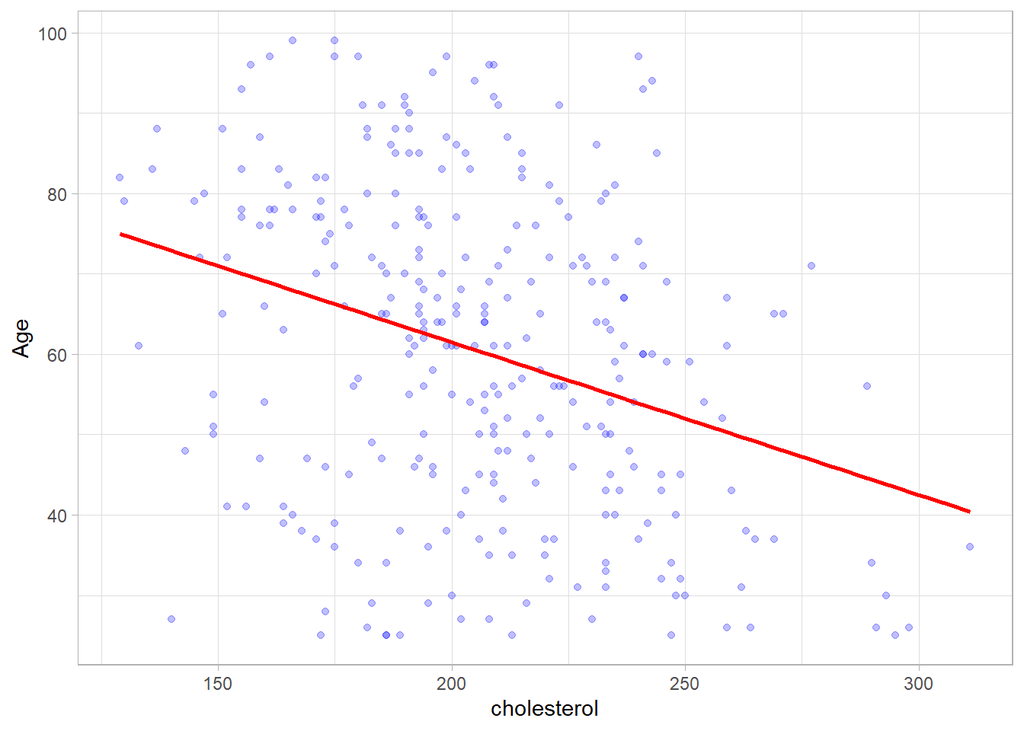

#### Équation du modèle

```
## [1] "Age =  99.48 -0.19 * cholesterol"
```

```
## [1] "R² =  0.1"
```

#### Vérification des hypothèse des résidus

```
## [1] -2.334475e-16
```

```
##
##  studentized Breusch-Pagan test
##
## data:  model7
## BP = 2.9769, df = 1, p-value = 0.08446
```

```
##
##  Shapiro-Wilk normality test
##
## data:  model7$residuals
## W = 0.98847, p-value = 0.01746
```

```
##
##  Durbin-Watson test
##
## data:  model7
## DW = 2.0783, p-value = 0.7531
## alternative hypothesis: true autocorrelation is greater than 0
```

#### Interprétation des résultats

**Qualité du modèle :** La pente négative signifie que plus le cholesterol est élevé, plus l’âge de décès diminue.

**Hypothèse des résidus :** Moyenne proche de 0 :validée

Normalité : non-validée, p-value < 0.05

Indépendance des erreurs : validée, statistique de test proche de 2 donc non-colinéarité

**Conclusion :** La qualité du modèle moyenne ansi que les hypothèses non validées nous permettent de conclure que le modèle linéaire n’est pas suffisant pour expliquer la relation entre le cholesterol et l’âge de décès.

### Conclusion générale

L’analyse réalisée montre que les relations entre les variables étudiées et l’âge de décès ne sont pas suffisamment expliquées par les modèles linéaires simples. Les faibles valeurs de R² observées dans l’ajustement du modèle de régression indiquent que les variables ne capturent pas entièrement la variabilité de l’âge de décès. Cela suggère que la relation entre ces facteurs est probablement plus complexe.

Pour essayer d’améliorer nos résultats, nous allons tenter d’utiliser des modèles multiples qui nous l’esperons nous permettrons d’obtenir de meilleur résultats et de définir un modèle qui expliquera et predira l’âge de décès

# 6.Modélisations statistiques

## 6.1 Choix des variables à inclure

Les méthodes de sélection de variables visent à simplifier les modèles en gardant uniquement les variables explicatives les plus pertinentes.

### Sélection ascendante et descendante

```r
intercept_only <- lm(age~1, data = Echantillon)
full_formula <- as.formula(paste("age ~", paste(names(Echantillon)[names(Echantillon) != "age"], collapse = " + ")))
all = lm(full_formula, data = Echantillon)
```

```r
modele_asc_desc$anova
```

```
##                      Step Df   Deviance Resid. Df Resid. Dev      AIC
## 1                         NA         NA       299  117798.79 1793.885
## 2             + addiction -1 23309.6138       298   94489.17 1729.737
## 3                   + hds -1 16861.6236       297   77627.55 1672.769
## 4              + num_meds -1 10065.5176       296   67562.03 1633.106
## 5          + drinks_aweek -1  4873.5630       295   62688.47 1612.645
## 6               + opioids -1  3330.9857       294   59357.48 1598.265
## 7           + cholesterol -1  3152.0459       293   56205.44 1583.896
## 8         + family_cancer -1  1383.5446       292   54821.89 1578.419
## 9                + smoker -1  1227.0101       291   53594.88 1573.628
## 10                  + sex -1  1025.0508       290   52569.83 1569.835
## 11            + nic_other -1   760.5898       289   51809.24 1567.462
## 12         + immune_defic -1   702.9066       288   51106.34 1565.364
## 13    + major_surgery_num -1   524.7491       287   50581.59 1564.268
## 14          + other_drugs -1   523.7957       286   50057.79 1563.145
## 15             + diabetes -1   496.6520       285   49561.14 1562.154
## 16 + family_heart_disease -1   457.7711       284   49103.37 1561.370
```

```r
#both$coefficients
```

#### Équation de régression du modèle

$\text{age}_i$ : Âge de décès estimé de l’individu $i$

$\text{num_meds}_i$ : Nombre de médicaments pris par l’individu $i$

$\text{cholesterol}_i$ : Taux de cholestérol de l’individu $i$

$\text{drinks_aweek}_i$ : Nombre de verres d’alcool consommés par semaine par l’individu $i$

$\text{immune_deficy}_i$ : Indicateur binaire de déficience immunitaire (1 si présent, 0 sinon)

$\text{major_surgery_num}_i$ : Nombre de chirurgies majeures subies par l’individu $i$

$\text{family_cancer}_i$ : Indicateur binaire de cancer dans la famille (1 si présent, 0 sinon)

$\text{diabetes}_i$ : Présence de diabète chez l’individu (1 si présent, 0 sinon)

$\text{other_drugs}_i$ : Indicateur d’utilisation d’autres drogues (1 si présent, 0 sinon)

$\text{smoking}_i$ : Indicateur de tabagisme (1 si fumeur, 0 sinon)

$\text{ls_danger_label_faible}_i$, $\text{ls_danger_label_moyen}_i$ : Indicateurs de niveaux de danger faibles ou moyens associés à l’environnement de l’individu

$\text{family_heart_disease}_i$ : Antécédents familiaux de maladies cardiaques (1 si présent, 0 sinon)

$\text{family_cholesterol}_i$ : Antécédents familiaux de cholestérol élevé (1 si présent, 0 sinon)

$\text{sys_bp}_i$ : Pression artérielle systolique de l’individu $i$

$\varepsilon_i$ : Erreur d’ajustement du modèle pour l’individu $i$

```r
summary(modele_asc_desc)
```

```
##
## Call:
## lm(formula = age ~ addiction + hds + num_meds + drinks_aweek +
##     opioids + cholesterol + family_cancer + smoker + sex + nic_other +
##     immune_defic + major_surgery_num + other_drugs + diabetes +
##     family_heart_disease, data = Echantillon)
##
## Residuals:
##     Min      1Q  Median      3Q     Max
## -30.997  -8.144   0.303   8.281  41.189
##
## Coefficients:
##                        Estimate Std. Error t value Pr(>|t|)
## (Intercept)           117.67263    5.80473  20.272  < 2e-16 ***
## addictiony            -13.05368    1.86188  -7.011 1.73e-11 ***
## hdsy                   -8.52778    1.84842  -4.614 6.00e-06 ***
## num_meds               -0.79998    0.17067  -4.687 4.30e-06 ***
## drinks_aweek           -0.70512    0.16212  -4.349 1.91e-05 ***
## opioidsy              -15.40396    3.61930  -4.256 2.83e-05 ***
## cholesterol            -0.12885    0.02889  -4.460 1.18e-05 ***
## family_cancery         -4.43220    1.59753  -2.774  0.00590 **
## smokery                -4.74082    1.80223  -2.631  0.00899 **
## sexm                   -4.04725    1.69183  -2.392  0.01740 *
## nic_othery             -3.80867    1.79861  -2.118  0.03508 *
## immune_deficy         -10.55018    4.84295  -2.178  0.03019 *
## major_surgery_num      -0.59927    0.33464  -1.791  0.07439 .
## other_drugsy           -6.33834    3.66329  -1.730  0.08468 .
## diabetesy              -4.69640    2.69128  -1.745  0.08206 .
## family_heart_diseasey  -4.05590    2.49264  -1.627  0.10481
## ---
## Signif. codes:  0 '***' 0.001 '**' 0.01 '*' 0.05 '.' 0.1 ' ' 1
##
## Residual standard error: 13.15 on 284 degrees of freedom
## Multiple R-squared:  0.5832, Adjusted R-squared:  0.5611
## F-statistic: 26.49 on 15 and 284 DF,  p-value: < 2.2e-16
```

#### Interprétation du modèle ajusté

Ce modèle montre que l’**âge de décès** (**ageᵢ**) est influencé par plusieurs facteurs.

#### Indices de performance du modèle

```r
performance(modele_asc_desc)
```

```
## # Indices of model performance
##
## AIC      |     AICc |      BIC |    R2 | R2 (adj.) |   RMSE |  Sigma
## --------------------------------------------------------------------
## 2414.733 | 2416.903 | 2477.698 | 0.583 |     0.561 | 12.794 | 13.149
```

#### Conclusion

En résumé, bien que le modèle soit **performant**, il reste possible de l’optimiser en simplifiant sa structure pour améliorer la **précision** et la **prédiction**.

### Approche exhaustive

**Objectif de la démarche**

Le modèle précédent contenait un grand nombre de variables explicatives, ce qui peut conduire à du surapprentissage (overfitting) et nuire à la performance du modèle sur de nouvelles données. Afin de voir si il est possible d’obtenir un modèle plus simple tout en conservant une bonne qualité de prédiction, nous allons effectuer une sélection exhaustive des variables.

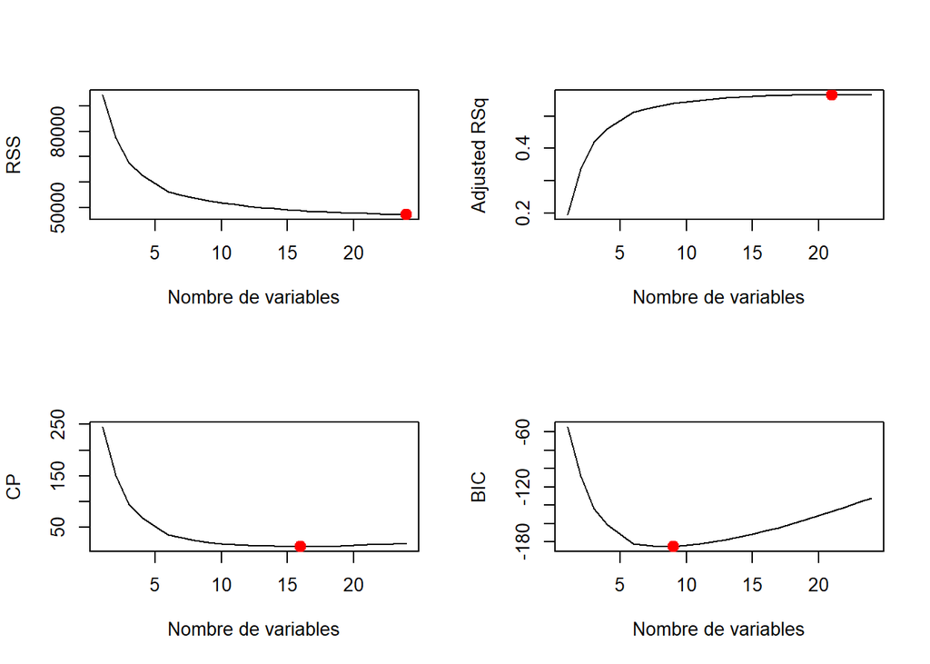

Les graphiques montrent que :

Le RSS diminue fortement jusqu’à environ 10 variables.

Le R² ajusté augmente sensiblement jusqu’à environ 10 variables puis se stabilise.

### Modèle exhaustif en prenant 10 variables maximum

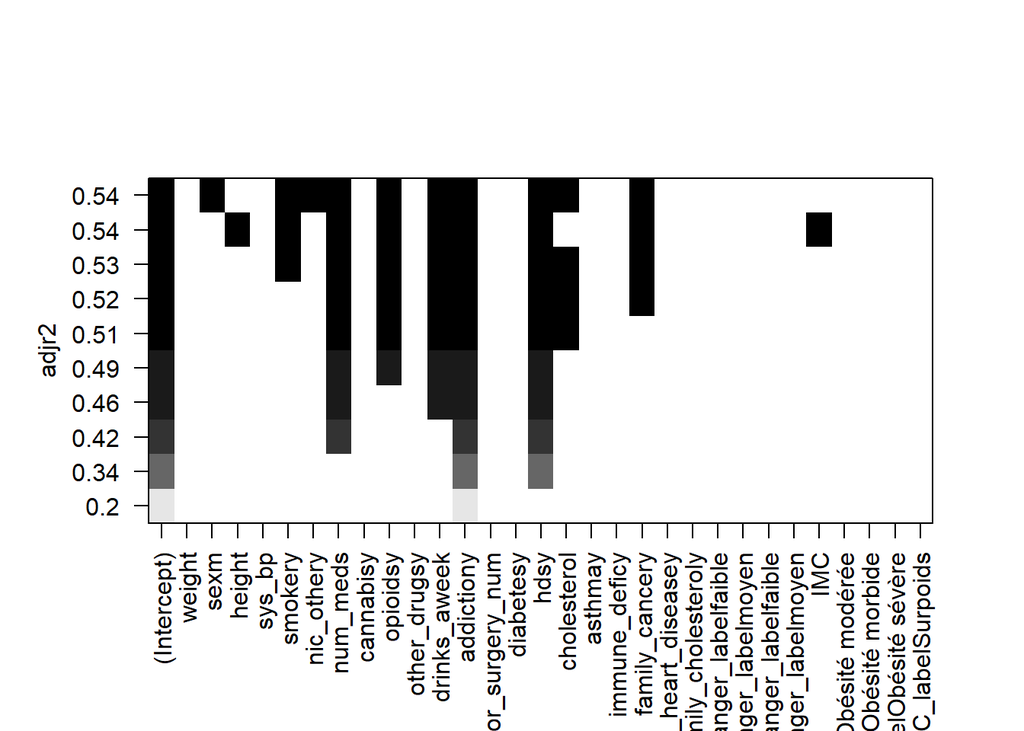

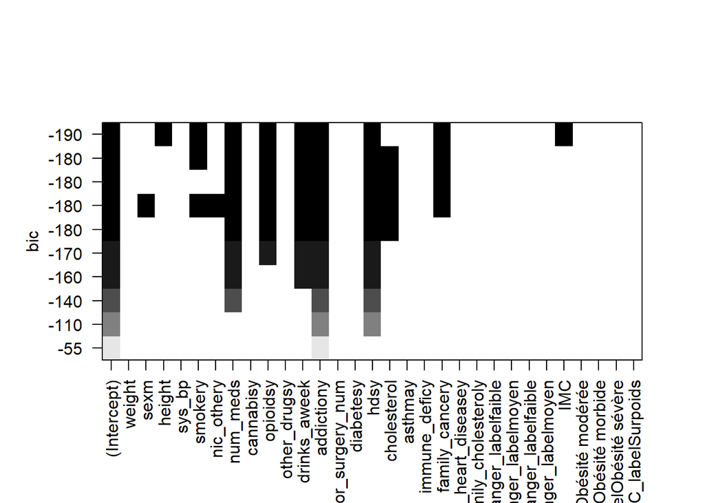

#### Équation de régression du modèle

```
##
## Call:
## lm(formula = formule, data = Echantillon)
##
## Residuals:
##     Min      1Q  Median      3Q     Max
## -32.172  -9.352   0.455   9.087  39.738
##
## Coefficients:
##                    Estimate Std. Error t value Pr(>|t|)
## (Intercept)       110.11371    5.62195  19.586  < 2e-16 ***
## sexm               -4.02899    1.73624  -2.321 0.021008 *
## num_meds           -0.82153    0.17326  -4.742 3.33e-06 ***
## opioidsy          -15.77706    3.67131  -4.297 2.36e-05 ***
## drinks_aweek       -0.71179    0.16480  -4.319 2.16e-05 ***
## addictiony        -13.80641    1.89453  -7.288 3.03e-12 ***
## major_surgery_num  -0.51265    0.34131  -1.502 0.134188
## hdsy               -9.90604    1.82460  -5.429 1.20e-07 ***
## cholesterol        -0.10440    0.02854  -3.658 0.000303 ***
## immune_deficy      -9.68639    4.95552  -1.955 0.051586 .
## family_cancery     -4.88571    1.63288  -2.992 0.003010 **
## ---
## Signif. codes:  0 '***' 0.001 '**' 0.01 '*' 0.05 '.' 0.1 ' ' 1
##
## Residual standard error: 13.52 on 289 degrees of freedom
## Multiple R-squared:  0.5519, Adjusted R-squared:  0.5364
## F-statistic: 35.59 on 10 and 289 DF,  p-value: < 2.2e-16
```

#### Équation ajustée du modèle

$$\begin{equation}
\widehat{\text{age}}_i = 110.114 -0.82 \cdot \text{num_meds}_i - 4.03
\cdot \text{sex}_i - 15.78 \cdot \text{opioids}_i - 0.712 \cdot
\text{drinks_aweek}_i - 13.81 \cdot \text{addiction}_i - 0.51 \cdot
\text{major_surgery_num}_i - 9.91 \cdot \text{hds}_i - 0.10 \cdot
\text{cholesterol}_i - 9.69 \cdot \text{immune_defic}_i - 4.89 \cdot
\text{family_cancer}_i
\end{equation}$$

Ce modèle met en évidence plusieurs facteurs influençant négativement l’âge de décès :

Facteurs réduisant l’espérance de vie :

- La consommation d’opioïdes est l’un des facteurs les plus impactants, réduisant l’âge de décès de 15.78 ans.
- L’addiction aux substances a également un effet marqué, diminuant l’espérance de vie de 13.81 ans.
- Les problèmes cardiaques ou AVC (hds) sont associés à une réduction de 9.91 ans de l’âge de décès.

Et toutes les autres variables qui ont toute dans ce cas un coefficient négatifs sont donc des facteurs importants dans la baisse de l’espérance de vie.

#### Performance du modèle exhaustif à 10 variables

```r
performance(modele_exh1_fi)
```

```
## # Indices of model performance
##
## AIC      |     AICc |      BIC |    R2 | R2 (adj.) |   RMSE |  Sigma
## --------------------------------------------------------------------
## 2426.455 | 2427.542 | 2470.900 | 0.552 |     0.536 | 13.265 | 13.515
```

### Modèle exhaustif en prenant 14 variables maximum

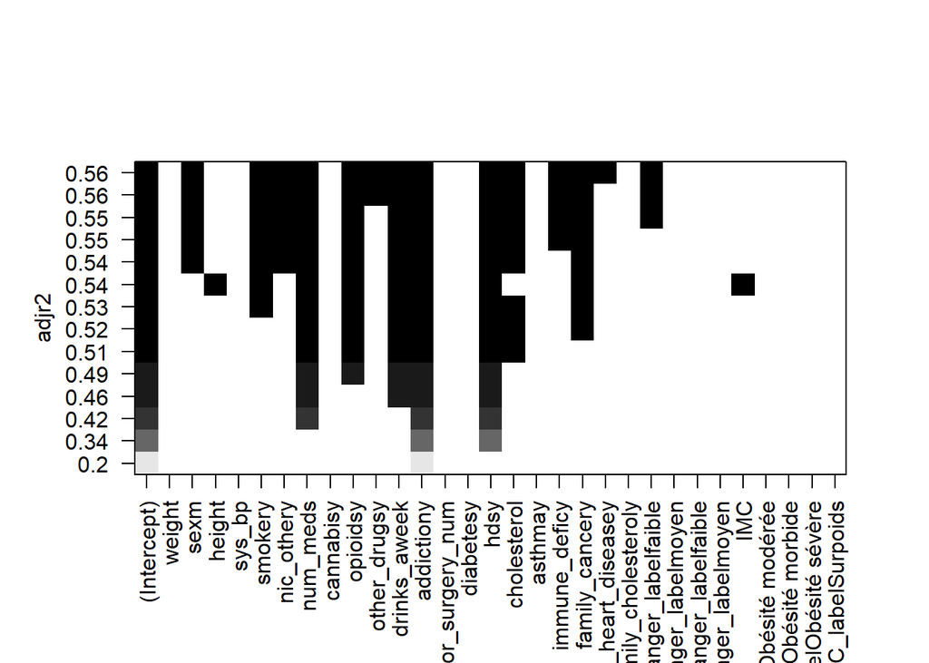

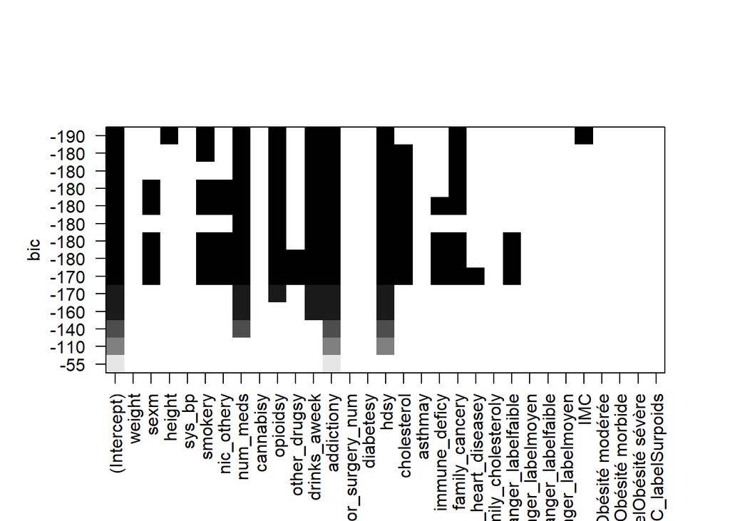

#### Équation de régression du modèle

```
##
## Call:
## lm(formula = formule, data = Echantillon)
##
## Residuals:
##     Min      1Q  Median      3Q     Max
## -32.176  -8.733   0.339   8.332  41.020
##
## Coefficients:
##                        Estimate Std. Error t value Pr(>|t|)
## (Intercept)           115.04650    5.90589  19.480  < 2e-16 ***
## sexm                   -4.04786    1.70742  -2.371  0.01842 *
## smokery                -4.45331    1.81649  -2.452  0.01482 *
## num_meds               -0.85405    0.17098  -4.995 1.03e-06 ***
## opioidsy              -15.18271    3.65046  -4.159 4.24e-05 ***
## other_drugsy           -7.14834    3.68997  -1.937  0.05371 .
## drinks_aweek           -0.65354    0.16490  -3.963 9.36e-05 ***
## addictiony            -13.28844    1.88366  -7.055 1.32e-11 ***
## major_surgery_num      -0.37892    0.34064  -1.112  0.26692
## diabetesy              -4.58244    2.71648  -1.687  0.09272 .
## hdsy                   -8.34445    1.86753  -4.468 1.14e-05 ***
## cholesterol            -0.13783    0.02928  -4.707 3.94e-06 ***
## immune_deficy         -10.16274    4.86418  -2.089  0.03757 *
## family_cancery         -4.49414    1.61293  -2.786  0.00569 **
## ls_danger_labelfaible   3.74770    2.05494   1.824  0.06924 .
## ls_danger_labelmoyen    1.80738    1.89231   0.955  0.34033
## ---
## Signif. codes:  0 '***' 0.001 '**' 0.01 '*' 0.05 '.' 0.1 ' ' 1
##
## Residual standard error: 13.24 on 284 degrees of freedom
## Multiple R-squared:  0.5772, Adjusted R-squared:  0.5549
## F-statistic: 25.85 on 15 and 284 DF,  p-value: < 2.2e-16
```

#### Équation du modèle ajusté

$$\begin{equation}
\widehat{\text{age}}_i = 115.05 -0.85 \cdot \text{num_meds}_i - 4.05
\cdot \text{sex}_i - 15.18 \cdot \text{opioids}_i - 0.65 \cdot
\text{drinks_aweek}_i - 13.29 \cdot \text{addiction}_i - 0.38 \cdot
\text{major_surgery_num}_i - 8.34 \cdot \text{hds}_i - 0.14 \cdot
\text{cholesterol}_i - 10.16 \cdot \text{immune_defic}_i - 4.49 \cdot
\text{family_cancer}_i- 4.45 \cdot \text{smoker}_i - 7.15 \cdot
\text{other_drugs}_i + 3.75 \cdot \text{ls_danger_label_faible}_i+ 1.81
\cdot \text{ls_danger_label_moyen}_i- 4.58 \cdot \text{diabetes}_i
\end{equation}$$

Ce modèle met en évidence plusieurs facteurs influençant l’âge de décès :

Facteurs réduisant l’âge de décès :

- La consommation de tabac réduit l’âge de décès de 4.45 ans.
- L’usage d’opioïdes a un effet encore plus marqué, diminuant l’espérance de vie de 15.18 ans.
- Les individus souffrant de diabète voient leur âge de décès réduit de 4.58 ans, soulignant l’impact négatif de cette maladie chronique.

et tous les autres variables avec un coefficient négatifs menent a une baisse de l’âge lors du décès.

Ce modèle met donc en évidence l’importance des comportements à risque et des conditions de vie sur l’espérance de vie.

#### Performance du modèle à 14 variables

```r
performance(modele_exh2_fi)
```

```
## # Indices of model performance
##
## AIC      |     AICc |      BIC |    R2 | R2 (adj.) |   RMSE |  Sigma
## --------------------------------------------------------------------
## 2418.971 | 2421.142 | 2481.936 | 0.577 |     0.555 | 12.884 | 13.242
```

## 6.2 Comparaison des différents modèles réalisées

Maintenant que nous avons crée 3 modèles différents de manières variées, nous devons déterminer le meilleur d’entres eux en choisissant un indicateur de réference.

Ici nous avons choisi de les comparer selon leur R2 ajusté car ce sont 3 modèles de taille différentes

```r
extraire_infos <- function(modele, nom, nb_vars) {
  summary_mod <- summary(modele)
  r2_adj <- summary_mod$adj.r.squared

  data.frame(
    Modèle = nom,
    Nb_Variables = nb_vars,
    R2_adj = round(r2_adj, 3)

  )
}

# Liste des modèles
modeles <- list( modele_asc_desc, modele_exh1_fi, modele_exh2_fi)
noms <- c( "Ascendante/Descendante", "Exhaustive 1", "Exhaustive 2")
nb_vars <- c(16, 10, 14)

# Appliquer la fonction à chaque modèle
resultats <- do.call(rbind, Map(extraire_infos, modeles, noms, nb_vars))

# Afficher le tableau
print(resultats)
```

```
##                   Modèle Nb_Variables R2_adj
## 1 Ascendante/Descendante           16  0.561
## 2           Exhaustive 1           10  0.536
## 3           Exhaustive 2           14  0.555
```

**Analyse comparative des modèles de régression :**

En comparant avec le R2 ajusté on voit que nos modèles sont proches les uns des autres en ce qui concerne cette valeur mais que le meilleur modèle qui ressort est celui trouvé avec la méthode ascendante-descendante. Nous allons donc utiliser ce modèle pour la suite de nos analyses et notamment pour notre tentative de prévision de l’âge de décès

Mais avant de le tester sur des prévisions, nous devons nous assurer sa validité. Il faut donc vérifier les différentes hypothèses que l’on pose lorsque nous posons un modèle linéaire multiple

## 6.3 Vérification des hypothèses du modèle asc desc

### Absence de multicolinéarité (VIF)

Une des première hypothèse que l’on pose est que nos variables explicatives sont non corrélées entres elles. Qu’en est il dans notre modèle :

```r
vif(modele_asc_desc)
```

```
##            addiction                  hds             num_meds
##             1.286599             1.480425             1.710496
##         drinks_aweek              opioids          cholesterol
##             1.249479             1.147555             1.605780
##        family_cancer               smoker                  sex
##             1.056666             1.127835             1.234922
##            nic_other         immune_defic    major_surgery_num
##             1.052453             1.056279             1.710915
##          other_drugs             diabetes family_heart_disease
##             1.035911             1.063482             1.055429
```

Le calcul des facteurs d’inflation de la variance (VIF) montre que toutes les variables ont un VIF inférieur à 2. Cela signifie qu’il n’y a pas de multicolinéarité problématique dans le modèle.

### Erreurs centrées autour de zéro

Ensuite nous faisons aussi l’hypothèse que les erreurs sont centrées reduites et ainsi qu’elles varient autour de 0 :

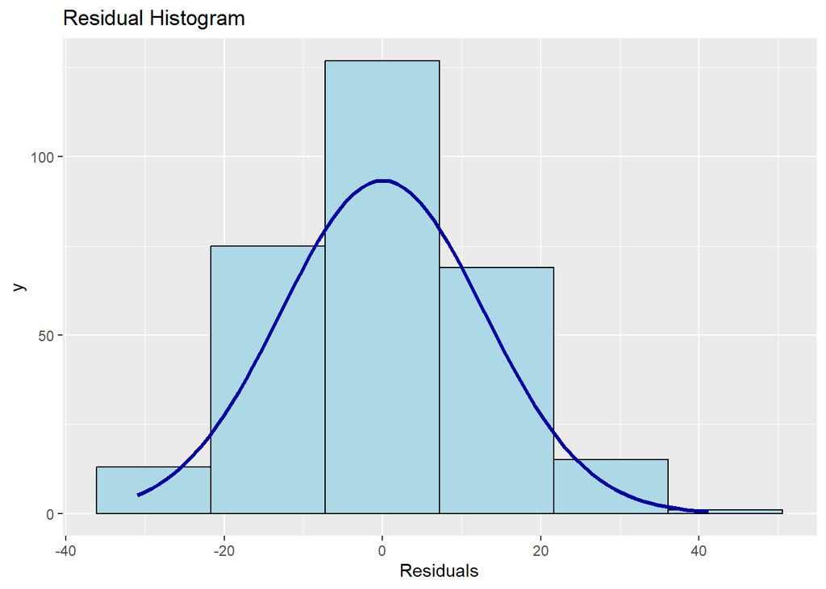

L’histogramme des résidus montre une distribution symétrique centrée sur zéro, ce qui suggère que les erreurs ont une espérance nulle, conformément à l’hypothèse du modèle linéaire.

### Erreurs de même variance (homoscédasticité)

Nous faisons aussi l’hypothèse que les résidus sont homoscédastiques, c’est à dire qu’ils sont de même variance

On utilise les test de Breush-Pagan :

**H0 : Les résidus sont homoscédastiques**

**H1 : Les résidus sont hétéroscédastiques**

```
##
##  studentized Breusch-Pagan test
##
## data:  modele_asc_desc
## BP = 15.226, df = 15, p-value = 0.4353
```

Le **test de Breusch-Pagan** retourne désormais une **p-value > 0.05***. Cela **indique que l’hypothèse d’homoscédasticité est respectée**.

### Erreurs indépendantes

On vérifie aussi que les erreurs ne sont pas corrélées entres elles avec le test de Durbin-Watson qui pose les hypothèses suivantes :

**H0 : Les erreurs sont indépendantes les unes des autres**

**H1 : Les erreurs sont autocorrélées**

```r
dwtest(modele_asc_desc)
```

```
##
##  Durbin-Watson test
##
## data:  modele_asc_desc
## DW = 2.1729, p-value = 0.9325
## alternative hypothesis: true autocorrelation is greater than 0
```

Le test de Durbin-Watson retourne une p-value bien supérieure au seuil de 0.05. Cela signifie que l’on ne rejette pas l’hypothèse d’indépendance des erreurs.

### Erreurs normalement distribuées

Enfin nous vérifions que les erreurs suivent une loi normale. Cette hypothès est celle qui nous permet notemmant d’utiliser des tests statitstiques sur notre modèle. On vérifie cette hypothèse graphiquement :

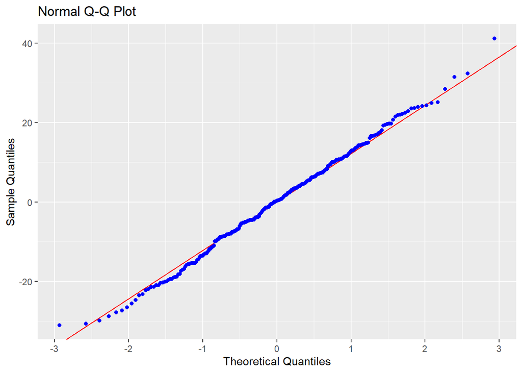

```r
qqplot = ols_plot_resid_qq(modele_asc_desc)
```

Le QQ Plot des résidus montre que la majorité des points suivent bien la droite théorique, suggérant que les erreurs suivent une distribution proche de la normale.

### Conclusion

Notre modèle valide bien toute ses hypothèses de départ. On est donc sures de la validité de notre test et pouvons continuer de l’utiliser.

## 6.4 Études individus levier et/ou atypiques

Dans ce genre de modèle, il est important de vérifier les individus atypiques ou levier car il peuvent nuire à la qualité de notre modèle notament en ce qui concerne les prévisions

### Graphique de la distance de Cook

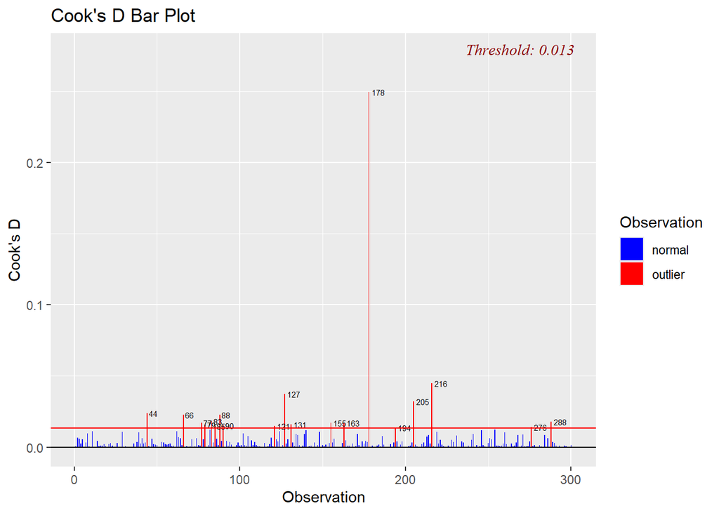

```r
ols_plot_cooksd_bar(modele_asc_desc)
```

Ce graphique des distances de Cook permet, dans un premier temps, d’identifier les individus atypiques et/ou influents. Nous devons poursuivre nos analyses pour déterminer lesquels sont atypiques, lesquels sont des leviers, ou ceux qui combinent les deux caractéristiques.

### Graphique des résidus studentisés

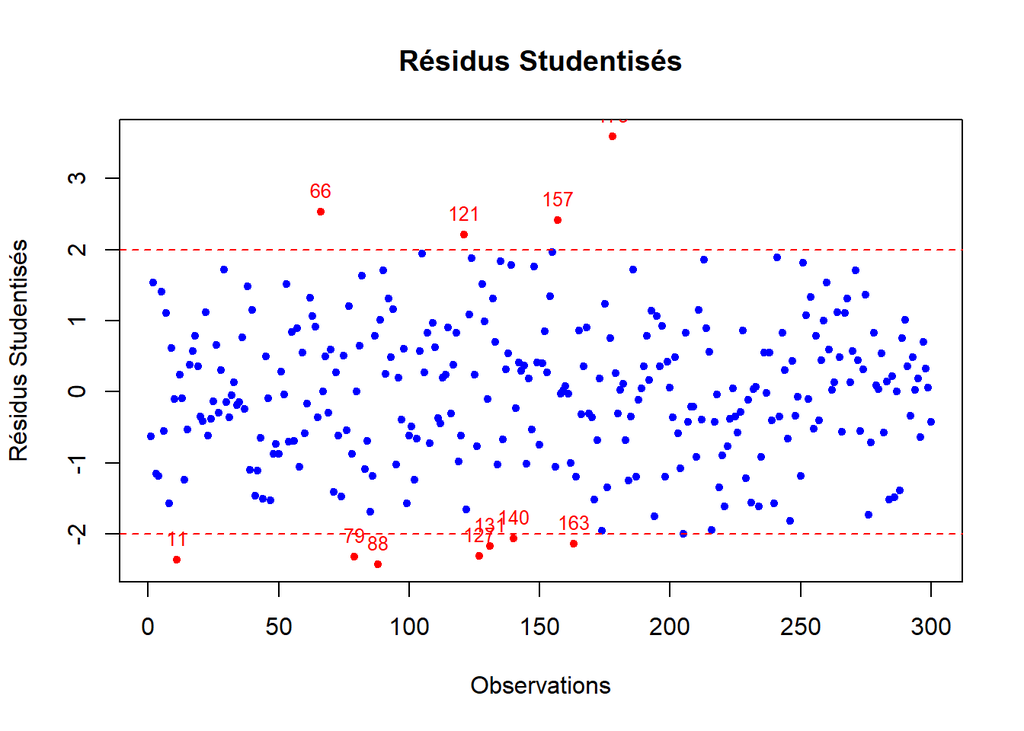

```r
seuil_residus = 2
r_student <- rstandard(modele_asc_desc) # Studentisation des résidus

plot(r_student, main = "Résidus Studentisés",
     ylab = "Résidus Studentisés",
     xlab = "Observations", pch = 20,
     col = ifelse(abs(r_student) > seuil_residus, "red", "blue"))
abline(h = c(-2, 2), col = "red", lty = 2)

# Identification des individus atypique (indice)
outliers <- which(abs(r_student) > seuil_residus)

text(outliers, r_student[outliers], labels = outliers, pos = 3, col = "red", cex = 0.8)
```

Ce graphique nous permet de mettre en valeur les individus atypiques, c’est-à-dire ceux qui sont mal expliqués par notre modèle. Tous les individus dont les résidus dépassent les seuils déterminés au niveau de 5 % sont considérés comme atypiques, car leurs résidus sont trop élevés par rapport aux autres observations.

En revenant sur les données, on remarque que certains individus atypiques, malgré des facteurs de risque comme le tabagisme, ont vécu plus longtemps que prévu selon notre modèle, ce qui suggère des facteurs non capturés par celui-ci. De plus, plusieurs individus sont décédés entre 20 et 30 ans, de manière inattendue par rapport à leurs consommation et modes de vie, probablement en raison d’événements externes ou de conditions non modélisées.

Ces observations soulignent les limites du modèle, qui peut expliquer la longévité dans la majorité des cas mais qui peux avoir du mal à prédire les décès prématurés ou exceptionnels.

### Graphique des individus leviers

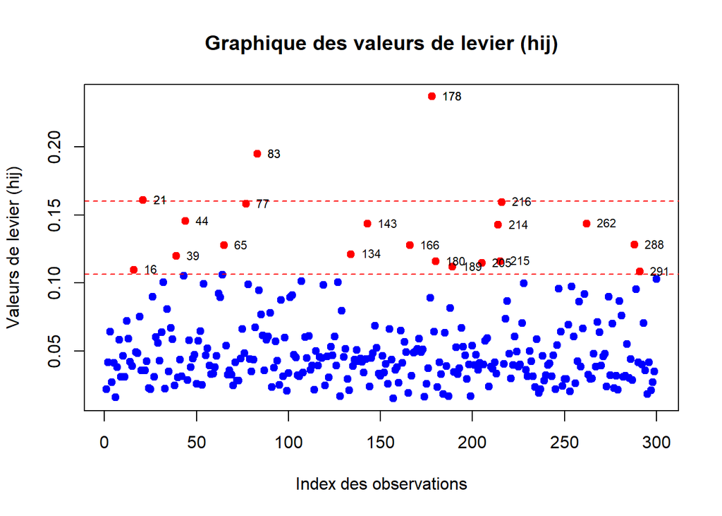

```r
# Identification des individus leviers
leverage = leverage_values <- hatvalues(modele_asc_desc)

# Graphique des valeurs de levier
plot(leverage,
     main = "Graphique des valeurs de levier (hij)",
     ylab = "Valeurs de levier (hij)",
     xlab = "Index des observations",
     pch = 19,
     col = "blue")

seuil_2 <- 2 * (length(coef(modele_asc_desc)) / nrow(Echantillon))  # Seuil classique
seuil_3 <- 3 * (length(coef(modele_asc_desc)) / nrow(Echantillon))  # Seuil plus strict

# Ajouter les seuils sur le graphique
abline(h = seuil_2, col = "red", lty = 2)  # Seuil classique
abline(h = seuil_3, col = "red", lty = 2)  # Seuil strict

# Mettre en évidence les points au-dessus des seuils
points(which(leverage > seuil_2), leverage[leverage > seuil_2], col = "red", pch = 19)
points(which(leverage > seuil_3), leverage[leverage > seuil_3], col = "red", pch = 20)

# Ajout des indices de lignes
text(which(leverage > seuil_2),
     leverage_values[leverage > seuil_2],
     labels = which(leverage > seuil_2),
     pos = 4,  # Position du texte : 4 correspond à droite du point
     cex = 0.7,  # Taille du texte
     col = "black")  # Couleur du texte

text(which(leverage > seuil_3),
     leverage_values[leverage > seuil_3],
     labels = which(leverage > seuil_3),
     pos = 4,
     cex = 0.7,
     col = "black")
```

Ce graphique permet d’identifier les individus influents ou leviers. Il comporte deux seuils : un seuil raisonnable et un seuil plus strict. Ce sont principalement les individus au-dessus du deuxième seuil qui peuvent nuire à notre analyse en introduisant des biais dans notre modèle, car ils influencent de manière significative les coefficients. Il faut donc par la suite que nous afassions attention à ces individus.

## 6.5 Prédictions

### Test de qualité des prédictions de notre modèle avec une validation croisée

```r
set.seed(314159)  # Choix d'une graine pour garantir la reproductibilité globale
K = 10  # Nombre de sous-échantillons (folds)
n = nrow(Echantillon)  # Nombre d'observations

# Fonction pour calculer la RMSE
rmse <- function(y_true, y_pred) {
  sqrt(mean((y_true - y_pred)^2))
}

# Nombre de répétitions
nbRep = 100

# Initialisation d'un vecteur pour stocker les RMSE moyennes à chaque répétition
rmse_mean_rep = numeric(nbRep)

# Boucle pour répéter la procédure nbRep fois
for (rep in 1:nbRep) {

  # Repartition aléatoire en sous-échantillons pour cette répétition
  Echantillon$FOLD = sample(x = rep(1:K, times=ceiling(n/K)), size=n)

  # Initialisation d'un vecteur pour stocker les RMSE de chaque fold
  rmse_values = numeric(K)

  # Validation croisée pour chaque répétition
  for (k in 1:K) {
    train_data = Echantillon[Echantillon$FOLD != k, ]  # Entraînement (tous les autres folds)
    test_data = Echantillon[Echantillon$FOLD == k, ]   # Test (le k-ième fold)

    # Entraîner le modèle (exemple avec une régression linéaire)
    model = lm(lm(age ~ weight + sex + smoker+ num_meds+ cannabis+ opioids+ other_drugs+ drinks_aweek+ addiction +         diabetes+ hds+ immune_defic+ family_cancer+ family_heart_disease + occup_danger_label+ls_danger_label, data =        train_data))

    predictions = predict(model,nexdata = test_data)

  rmse_values[k]= rmse(test_data$age, predictions)

    # Prédictions sur l'ensemble de test
    predictions = predict(model, newdata=test_data)

    # Calcul de la RMSE pour ce fold
    rmse_values[k] = rmse(test_data$age, predictions)
  }

  # Calcul de la RMSE moyenne pour cette répétition
  rmse_mean_rep[rep] = mean(rmse_values)
}

# Affichage des résultats
rmse_mean_final = mean(rmse_mean_rep)
rmse_mean_final
```

```
## [1] 13.6933
```

```r
rmse_quantiles = quantile(rmse_mean_rep, c(0.025, 0.975))
rmse_quantiles
```

```
##     2.5%    97.5%
## 13.51769 13.87430
```

```r
sd(Echantillon$age)
```

```
## [1] 19.84883
```

Avec ces résultatat on trouve un RMSE inferieur à l’écart type de l’âge dans notre échantillon. Cela signifie que notre modèle capture une part significative de la variabilité de l’âge et offre de meilleures prédictions que si on se basait uniquement sur la dispersion naturelle des âges dans l’échantillon.

### Visualisation graphique des âge prédits en fonction des âges de notre jeu de données

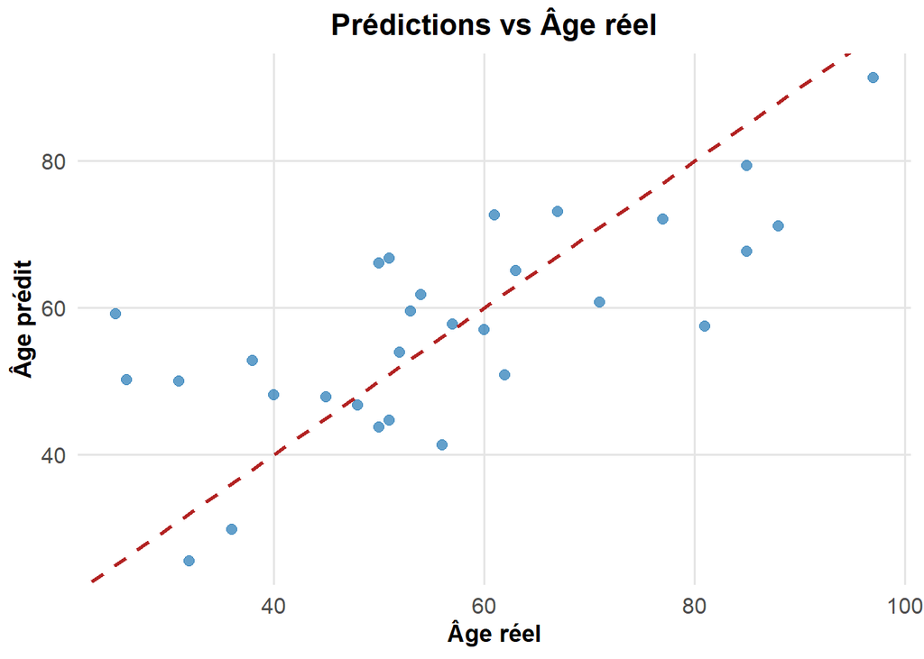

```r
comparison_df <- data.frame(True_Age = test_data$age, Predicted_Age = predictions)

p <- ggplot(comparison_df, aes(x = True_Age, y = Predicted_Age)) +
  geom_point(alpha = 0.7, color = "#1F77B4", size = 2.5) +  # Points bleus foncés

  # Ligne parfaite où âge réel = âge prédit
  geom_abline(slope = 1, intercept = 0, color = "firebrick", linetype = "dashed", size = 1) +

  # Titre et axes
  labs(
    title = "Prédictions vs Âge réel",
    x = "Âge réel",
    y = "Âge prédit"
  ) +

  # Thème propre et minimaliste
  theme_minimal(base_size = 14) +
  theme(
    plot.title = element_text(hjust = 0.5, face = "bold", size = 16),
    axis.title = element_text(face = "bold", size = 13),
    axis.text = element_text(size = 12),
    panel.grid.major = element_line(color = "gray90"),
    panel.grid.minor = element_blank()
  ) +

  # Ajustement de l'affichage sans forcer un rapport 1:1
  coord_cartesian()
# Affichage du graphique
print(p)
```

Ce graphique nous permet de confirmer que notre modèle à l’air de plutôt bien prédire nos variables. Mais pour vérifier concrétement si il peut être utiliser en tant que modèle de prédiction, on peux le tester sur un cas réel

# 7.Test de notre modèle sur un cas concret

Nous allons le tester à partir des données d’une célébrité décédée et voir si notre modèle arrive à prédire l’âge de décès.

Nous avons choisi de le tester sur Marilyn Monroe car elle est décédée d’une overdose et c’était une personnalité connue, ce qui nous permet de trouver et estimer plus facilement les données dont on a besoin pour notre modèle.

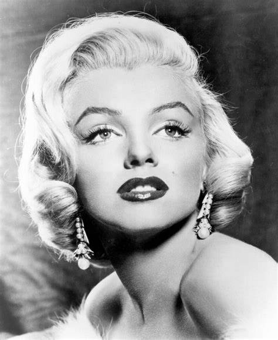

On créer donc un jeux de données contenant les données concernant Marilyn Monroe et on lance la prédiction.

```r
# Création de Marilyne Monroe en tant que jeu de données
marilyn_data <- data.frame(
  num_meds = 6,
  cholesterol = 200,
  drinks_aweek = 10,  # alcoolique
  immune_deficy = "n",
  opioids = "y",  # dépendance aux antidépresseurs
  addiction = "y",
  hds = "n",
  sex = "f",
  major_surgery_num = 2,  # Nombre de chirurgies majeures
  family_cancer = "n",
  diabetes = "n",
  other_drugs = "y",
  smoker = "y",  # Fumeuse
  ls_danger_label="moyen",  # Pas de mode de vie à danger moyen
  family_heart_disease = "n",
  family_cholesterol = "n",
  occup_danger_label = "moyen",
  sys_bp = 120,
  nic_other = "n",
  immune_defic = "n"
)


# Prédiction de l'âge au décès pour Marilyn Monroe
predicted_age <- predict(modele_asc_desc, newdata = marilyn_data, interval = "prediction")

# Affichage du résultat
predicted_age
```

```
##        fit      lwr      upr
## 1 39.31722 11.31628 67.31816
```

Marilyn Monroe est décédée à l’âge de 36 ans d’une overdose. Selon notre modèle on trouve un âge de décès de 39,32 ans ce qui se rapproche plutôt de la réalité.

Intervalle de prédiction : [11.32 ; 67.32]

On trouve aussi une intervalle de prédiction importante, ce qui est plutôt commun quand nous faisons de la prédiction.

Conclusion :

Notre modèle semble notamment bien capturer l’impact de la santé, des habitudes de vie et des conditions environnementales. Cependant, il est important de noter que ce modèle ne peut pas prédire des décès soudains tels que ceux causés par des accidents car ces événements échappent aux facteurs que nous avons modélisés.

En outre notre modèle semble fiable pour l’estimation de l’âge de décès à partir de ces variables. En effet, les résultats théoriques et pratiques indiquent que le modèle pourrait constituer un bon outil de prédiction.

Ainsi, ce modèle pourrait non seulement être un bon moyen de comprendre certains déterminants de l’espérance de vie mais aussi offrir une base solide pour la prédiction de celle-ci.